# Cederlof-AdvanceLayoffNotice-2021-CEPR.pdf

Converted from PDF `Cederlof-AdvanceLayoffNotice-2021-CEPR.pdf` · 63 pages · anchors: page `#pN`, block `#pN-bK`

Page 1

## **DISCUSSION PAPER SERIES**

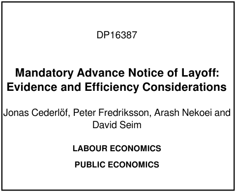

NOTE: figure/graphic rendered as an image from the PDF; its content is not machine-readable text. Caption (if any) follows as the next block.

**text found inside the figure**

DP16387

**Mandatory Advance Notice of Layoff: Evidence and Efficiency Considerations**

Jonas Cederlöf, Peter Fredriksson, Arash Nekoei and

David Seim

**LABOUR ECONOMICS**

**PUBLIC ECONOMICS**

Electronic copy available at: https://ssrn.com/abstract=3928666

Page 2

*ISSN 0265-8003*

## **Mandatory Advance Notice of Layoff: Evidence and**

## **Efficiency Considerations**

*Jonas Cederlöf, Peter Fredriksson, Arash Nekoei and David Seim*

Discussion Paper DP16387

Published 22 July 2021 Submitted 16 July 2021

Centre for Economic Policy Research 33 Great Sutton Street, London EC1V 0DX, UK

Tel: +44 (0)20 7183 8801

www.cepr.org

This Discussion Paper is issued under the auspices of the Centre’s research programmes:

Labour Economics Public Economics

Any opinions expressed here are those of the author(s) and not those of the Centre for Economic Policy Research. Research disseminated by CEPR may include views on policy, but the Centre itself takes no institutional policy positions.

The Centre for Economic Policy Research was established in 1983 as an educational charity, to promote independent analysis and public discussion of open economies and the relations among them. It is pluralist and non-partisan, bringing economic research to bear on the analysis of medium- and long-run policy questions.

These Discussion Papers often represent preliminary or incomplete work, circulated to encourage discussion and comment. Citation and use of such a paper should take account of its provisional character.

Copyright: Jonas Cederlöf, Peter Fredriksson, Arash Nekoei and David Seim

Electronic copy available at: https://ssrn.com/abstract=3928666

Page 3

## **Mandatory Advance Notice of Layoff: Evidence and**

## **Efficiency Considerations**

### **Abstract**

We investigate a prevalent, but understudied, employment protection policy: mandatory advance notice (MN), requiring employers to notify employees of forthcoming layoffs. MN increases future production, as notified workers search on the job, but reduces current production as they supply less effort. Our theoretical model captures this trade-off and predicts that MN improves production efficiency by increasing information sharing, whereas large production losses can be avoided by worker-firm agreements on side-payments – severance pay – in lieu of MN. We provide evidence of such severance increases in response to an extension of MN using novel Swedish administrative data. We then estimate the production gain of MN: extending the MN period leads to shorter non-employment duration and higher reemployment wages, plausibly driven by on-thejob search. Using variation in notice duration across firms, we estimate the productivity loss of notice. The estimates of benefits and costs suggest that MN has a positive net impact on production, offering an empirically-grounded efficiency argument for mandating notice.

JEL Classification: J31, J33, J63, J68

Keywords: unemployment, Advance Notice, job mobility, job quality

Jonas Cederlöf - jonas.cederlof@ed.ac.uk *University of Edinburgh*

Peter Fredriksson - peter.fredriksson@nek.uu.se *Uppsala University*

Arash Nekoei - arash.nekoei@iies.su.se *IIES and CEPR*

David Seim - david.seim@ne.su.se *Stockholm University and CEPR*

Powered by TCPDF (www.tcpdf.org)

Electronic copy available at: https://ssrn.com/abstract=3928666

Page 4

### Mandatory Advance Notice of Layoff:

### Evidence and Efficiency Considerations*<sup>∗</sup>*

Jonas Cederlöf, Peter Fredriksson, Arash Nekoei, David Seim

July 16, 2021

#### **Abstract**

We investigate a prevalent, but understudied, employment protection policy: mandatory advance notice (MN), requiring employers to notify employees of forthcoming layoffs. MN increases future production, as notified workers search on the job, but reduces current production as they supply less effort. Our theoretical model captures this trade-off and predicts that MN improves production efficiency by increasing information sharing, whereas large production losses can be avoided by worker-firm agreements on side-payments – severance pay – in lieu of MN. We provide evidence of such severance increases in response to an extension of MN using novel Swedish administrative data. We then estimate the production gain of MN: extending the MN period leads to shorter non-employment duration and higher reemployment wages, plausibly driven by on-the-job search. Using variation in notice duration across firms, we estimate the productivity loss of notice. The estimates of benefits and costs suggest that MN has a positive net impact on production, offering an empirically-grounded efficiency argument for mandating notice.

Keywords: Unemployment, Advance notice, Job mobility, Job Quality. JEL-codes: J31; J33; J63; J68.

A fundamental challenge for economists and policymakers alike is to design programs that facilitate

the transition of laid-off workers to a new job. The policy that has received most attention in this

context has certainly been unemployment insurance (UI), where the government takes on the onus of

supporting unemployed during their job search period.

Mandatory advance notice of layoff (MN) is an alternative policy to achieve a smoother transition

across jobs for laid-off workers. MN requires that employers notify workers in advance before layoff.

During the notice period, workers continue to work and stay on the payroll. In this way, MN acts like

a fully experience-rated UI system with complete insurance during the notice period. All OECD

countries have MN programs. In the U.S., for example, the Worker Adjustment and Retraining

*∗*First complete draft: 1 December 2019. We thank Raj Chetty, Caroline Johansson, Benjamin Schoefer, Jesse Shapiro, and seminar participants at NBER Summer Institute 2020, AEA 2018, Aarhus University, CEPR-conference 2018, CREST, Stockholm University, Labor Economics Workshop 2018, Nordic Summer Institute in Labor Economics 2018, the 10th Nordic Register Data and Economic Modeling Meeting, the UCLS annual conference, and the University of Copenhagen. Per Lindberg and Fabian Sinn provided excellent research assistance.

1

Electronic copy available at: https://ssrn.com/abstract=3928666

Page 5

Notification (WARN) act of 1988 requires large employers a 2-month advance notice.<sup>1</sup> Despite the

prevalence of MN policies, few papers have examined their normative implications, and there is a

void of credible evidence on the effects of such programs.

This paper puts MN in the spotlight by investigating its potential from a theoretical and an

empirical perspective. Our theory shows how MN can improve efficiency as it provides workers

with more time to search on the job. But MN also reduces production as notified workers supply

less effort. A key insight of the theory is that the production loss is attenuated if severance pay is

used when information sharing is detrimental to efficiency. Empirically, we estimate the impact of

MN on the behavior of employees and employers using novel data on notifications from Sweden and

four research designs: a Regression Discontinuity (RD) design, an instrumental variables approach,

as well as difference-in-differences and bunching analysis. We find that severance pay increases when

the MN period is extended, which is consistent with firms undoing the law.<sup>2</sup> We also find that MN

raises wages at the next job and shortens the exposure to non-employment, but the productivity of

notified employees drops.

Our theoretical model incorporates a trade-off in providing notice: Notified workers intensify

their on-the-job search and supply less effort on the job. Both of these behaviors reduce current

production, but intensified job search increases future employment and production. The current

employer has no direct incentive to share information about planned layoffs as it does not internalize

these benefits. MN prescribes information sharing and changes the property rights over information.

But if the market equilibrium is efficient, MN has no impact on outcomes because when the

production loss from information sharing is high, severance pay is used in lieu of notice. However,

the same mechanism helps to increase efficiency in the presence of frictions, e.g., due to workers

under-estimating the risk of layoff. When advance notice is under-provided in equilibrium – because

workers do not value information sharing sufficiently – MN corrects this distortion. In fact, additional

notice will only be provided when frictions prevent efficient information-sharing, while inefficient

information-sharing is avoided using severance.

We bring these theoretical insights to the data. Our goal is to investigate whether severance pay

is used instead of notice, and to estimate the production gains and losses of notice. To achieve these

objectives, we must overcome three hurdles. First, to observe individual-level notification, we use

unique and novel administrative data from Sweden. Second, to estimate the causal effects of MN, we

exploit an age-based discontinuity from Swedish collective agreements. Third, to measure severance

payments, we develop a simple method using annual earnings and employment spell data that is

generalizable to other countries and contexts.

Our RD estimates reveal that employers do provide longer notice periods to workers entitled

to extended MN. Longer MN also increases severance pay. In light of our theory, the increase in

the notice period indicate the presence of frictions, and the usage of side-payments suggests that

information sharing is not always efficient. On net, MN leads to a smoother transition across jobs

(shorter non-employment duration) and better subsequent job matches (higher wages). The wage

1The state of New York extended the mandatory notice period to 90 days in 2009, and New Jersey is currently considering a similar extension (Krolikowski and Lunsford, 2020).

2Both in Sweden and in the U.S., it is legal to sidestep the MN requirement with bilaterally-agreed payments.

2

Electronic copy available at: https://ssrn.com/abstract=3928666

Page 6

gain occurs mainly for workers who transition to a new job without a spell of unemployment. Higher

severance, lower non-employment, and higher wages yield an increase in post-notification earnings

corresponding to 13% of annual earnings. Shorter non-employment, higher severance and wages

contribute to 50%, 35%, and 11% of this earnings increase, respectively.<sup>3</sup>

To distinguish the effects of MN that arise due to extended notice periods or higher severance pay,

we exploit an additional source of exogenous variation stemming from spill-overs across workers

within the same layoff. Using our age-based RD-design, we first show that longer (de jure) MN of

a worker causes longer actual (de facto) notice of her co-workers. Our additional instrument — the

share of laid-off co-workers above age 55 — leverages this fact. We find that the earlier the worker

is aware of future layoff, the shorter is her exposure to non-employment, and the higher is the wage

of her future job. Severance pay has no impact on future wages but lengthens non-employment

duration.

Importantly, workers notified a month earlier find a job paying 1.8% higher wages. This is

substantially larger than the UI wage effects documented in the prior literature.<sup>4</sup> This points to the

effectiveness of on-the-job search compared to search while unemployed; slower skill deterioration

and no stigma of prolonged on-the-job search, imply that workers can be more selective in their job

search without suffering from declining opportunities (negative duration dependence).

In the second part of our empirical analysis, we provide evidence regarding the costs of the policy.

We first exploit legislation that requires employers to report to the Public Employment Service any

layoff of at least 26 workers a minimum of four months in advance. We show that this requirement is

mainly relevant for firms that would like to give workers advance notice – i.e., when the productivity

loss of notice is low – and lay off workers with less than four months of mandatory notice. Such firms

have an incentive to lay off only 25 workers (i.e., bunch) and retain other workers temporarily. Our

empirical analysis documents substantial bunching at and below 25 workers. As predicted, excess

mass is larger, the higher is the share of workers eligible for less than four-months of MN. Although

indicating that that the productivity loss due to notice is moderate – at least in some firms – this

exercise does not provide a quantitative estimate of the productivity loss of notice.

To estimate the productivity loss of having workers on notice, we use variation in notice duration

across firms in a difference-in-differences framework. Holding layoff size constant, we show that the

revenue per effective worker falls for firms where notified workers remain longer on the payroll. A

causal interpretation of this analysis requires the assumption that productivity would evolve similarly

in the absence of layoff for similar firms with different average notice duration. The fact that the

pre-notification evolution of the marginal revenue product is unrelated to subsequent average notice

duration across firms support this assumption. The temporary nature of the effects suggests that

differences in the composition of laid-off workers, which are correlated with average notice duration,

are not likely to be the driver of the productivity loss. Our estimates suggest a 35% productivity loss

of notified worker relative to other workers.

Third, we show that severance is not paid in displacements involving cash-constrained firms. This

is problematic, as the normative case for MN relies on firms being able to use severance payments to

3The remaining 4% has to do with the transition from the old to the new job. 4See Nekoei and Weber (2017) for a review of the evidence on the UI wage effect.

3

Electronic copy available at: https://ssrn.com/abstract=3928666

Page 7

avoid cases where the productive loss of notice is larger then the gains for workers. In the light of our

theory, this evidence suggests that MN can impose an efficiency loss for cash-constrained firms.

Finally, we pull the pieces together by comparing the size of the production gains and losses of

the MN policy. The production gains consist of the positive wage effect plus the shorter duration

of non-employment, which should be compared with the productivity loss of notice. Our estimates

suggest that the net impact of the policy on average production is positive. In fact, the gains are so

large that the productivity loss of notice would have to be in the excess of 80 percent — our estimate

corresponds to 35 percent — for the policy to negatively impact production efficiency. The main

caveat to these results is that the policy may affect the hiring margin. Hiring will be impacted if

firms cannot shift the average cost of the policy onto workers in the form of a reduction in wages.

Moreover, the positive impact on production contributes to a positive fiscal externality, which is

further enhanced by a reduction in unemployment expenditure. To give a sense of the magnitudes

involved, the increase in production corresponds to 88% of a monthly wage, and the fiscal externality

to 71% of a monthly wage.

Our paper is related to several strands of the literature. The empirical evidence on MN mainly

comes from the research during the decade after the introduction of the WARN act of 1988; see, e.g.

Ruhm (1992, 1994), Burgess and Low (1992) and Jones and Kuhn (1995). Papers in this literature

mainly compare workers in firms subject to the WARN act to workers in firms which are not,

controlling for a rich set of covariates. Our finding that MN helps workers to find a better job

emphasizes the effectiveness of on-the-job search, echoing the similar pattern in survey data (Blau

and Robins (1990) and Faberman et al. (2021)).

With respect to the theoretical literature, Pissarides (2001) focuses on the insurance properties of

advance notice. He shows that advance notice can be a part of an optimal contract, as it effectively

provides an alternative insurance mechanism for workers. There are only a few examining the

efficiency properties of MN. In the settings of Kuhn (1992) and Deere and Wiggins (1988), MN plays

the role of a commitment device for employers. We discuss such cases, but also consider cases where

notice is contractable but under-appreciated by workers. Our main theoretical point is valid no matter

the source of friction: MN is efficiency-enhancing, as severance can be used to undo the inefficient

part of the program.

More generally, our theoretical findings relate to Lazear (1990), who show that public policies (in

his case severance pay) will be undone by private contracts in the absence of transaction costs. One

general lesson from our paper is the importance of studying why and how labor laws are sidestepped

using private contracts. In contrast to Lazear (1990), there are potential benefits of the public policy

in our setting. We thus show that bypassing the law with a bilateral agreement can be efficiency-

enhancing since it allows the agents to avoid the policy when it is inefficient.

The paper unfolds as follows. Section 1 provides a framework that guides our empirical analysis.

Section 2 describes the institutional setting for our empirical work as well as the data used. Sections 3

and 4 provide our empirical analysis of the benefits and costs of MN, respectively. Section 5 connects

the empirical results to the theory and calculates the efficiency effect of MN. Section 6 concludes.

4

Electronic copy available at: https://ssrn.com/abstract=3928666

Page 8

### **1 Conceptual Framework**

This section provides a simple framework that guides our empirical analysis. We first examine the

role of MN in the case of exogenous private contracts, and then consider the polar case of endogenous

efficient contracts that can adjust fully in response to MN. Finally, we discuss the more realistic case

of endogenous contracts with frictions. The full treatment of these cases is provided in Appendix A.

#### **1.1 The Theoretical Setting**

We consider a two-period model. Production is the result of a match between a worker and an

employer. Workers are homogeneous and risk-neutral. The risk neutrality assumption, a deviation

from the literature, allows us to focus on the first-order impact on productive efficiency (rather than

insurance). For now, there is free entry and perfect competition among employers.<sup>5</sup>

In the first period, production is “high”, and equal to Y. In the second period, production remains

high with probability θ or drops to zY with probability 1 −θ. At the beginning of the two periods,

the worker is hired with a contract specifying a wage, a severance payment and an advance notice

requirement, (wY, sY, δ *∈*{0, 1}). Without loss of generality, we normalize Y = 1. The contracted wage

is fixed for both periods, with no possibility of renegotiation. This assumption leads to separation in

case of a productivity drop in the second period.

Just after signing the contract, the employer receives private information about the productivity

of the match in the second period. The information is verifiable: the employer may share this

information with the employee, i.e., giving her advance notice, at the start of the first period.

When an employee receives advance notice, her productivity falls for two reasons: first she

starts to look for alternative employment (on-the-job search); second, work effort decreases (i.e., she

“shirks”) since work incentives have fallen. Together, these two forces lower production by a factor

α *∈*[0, 1), to which we refer as “productivity loss of notice”.

Safe jobs are available in the second period; they have productivity ρ < 1, which captures the

displacement effect (e.g., Jacobson et al., 1993). Laid-off workers will find such a job with probability

e.<sup>6</sup>

On the job search is productive. It increases both the likelihood of finding a job in the second

period by ∆e and the wage in the new job by ∆ρ (Acemoglu and Shimer (1999), Faberman et al. (2021)).

We denote the total expected production increase due to notice by σ, σ *≡*(e + ∆e)(ρ + ∆ρ) −eρ.<sup>7</sup>

The trade-off in providing notice is between the production loss of notice, α, and the production

gain due to on-the-job search for the worker, σ. First-best information sharing (advance notice) occurs

when the productivity loss in the first period is smaller than the gain from notice, i.e., if and only if

α < σ. By contrast, providing severance pay does not involve the same trade-off since it lacks the

information sharing aspect.

5This assumption and many other aspects of the setting are borrowed from Blanchard and Tirole (2008). We also follow them in focusing on the optimal contract and to characterize the equilibrium.

6To make the setting interesting to study, we assume that the the outside option is better than remaining in a lowproductive job, eρ > z (see Appendix A).

7To focus on productive efficiency, we ignore the disutility cost of working and searching. To incorporate such costs, we would have to adjust eρ and σ.

5

Electronic copy available at: https://ssrn.com/abstract=3928666

Page 9

#### **1.2 The Role of Mandatory Notice of Layoff (MN)**

**Exogenous contracts** In this section, we first study the role of MN in the case of an exogenous

contract without advance notice, (w, s, 0). This is a partial equilibrium analysis – in fact, it is the

counterpart of Baily-Chetty setting for the analysis of optimal UI, applied to the case of advance

notice (Baily, 1978; Chetty, 2006).

In the absence of MN, employers do not provide advance notice. The reason is simply that

employers do not internalize the gain accruing to the employee but they bear the entire cost. The

expected profit equals<sup>8</sup>

π0 = (1 −w) | {z } 1st period

+ θ *×* (1 −w) + (1 −θ) *×* (−s) | {z } 2nd period

(1)

Now, if labor law mandates advance notice, the employer has three options. The first option is

to provide advance notice, which reduces expected profit by the (expected) production loss of notice;

the expected profit associated with this option is thus π0 −(1 −θ) α. The second option is to not

provide advance notice, but compensate the worker ex post with an additional severance payment

of σ; an additional severance payment of σ exactly compensates for what the worker lost by not

getting advance notice. The expected profit associates with this second option is π0 −(1 −θ) σ. The

third option is to notify the worker in the second period, such that the productivity loss of notice

occurs during the low productivity period. This “labor-hoarding” strategy leads to the profit of

π0 −(1 −θ) Ξ, where Ξ *≡*w −(1 −α) z.

1

45<sup>𝑜𝑜</sup>

**equation / math rendering (image)**

NOTE: contains mathematical notation; text above is the PDF text layer and symbols may be mis-extracted. Image shows the original.

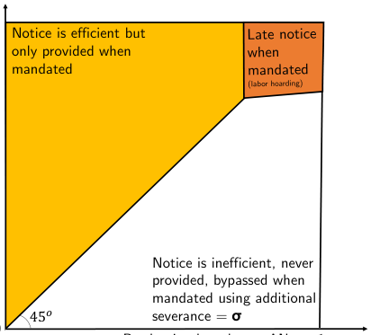

NOTE: figure/graphic rendered as an image from the PDF; its content is not machine-readable text. Caption (if any) follows as the next block.

**text found inside the figure**

Notice is efficient but only provided when mandated

Notice is inefficient, never provided, bypassed when mandated using additional severance = **σ**

On the job search relative effectiveness

#### **σ**

Figure 1: Provision of advance notice and the role of mandated notice (MN) Note: This figure illustrates how MN affect the allocation of notice and severance pay in the setting with an exogenous

contract. Appendix A provide similar illustrations for the case of an endogenous contract, with or without frictions.

8For the sake of simplicity, we ignore discounting.

6

Electronic copy available at: https://ssrn.com/abstract=3928666

Page 10

Figure 1 illustrates the optimal actions that the employer would take:

1. Notifying the worker in advance when min (σ, α, Ξ) = α. MN increases production by ∆W = (1 −θ) σ from the base of W0 = 1 + θ + (1 −θ) eρ.

2. Side-stepping notice using severance when min (σ, α, Ξ) = σ. Severance is thus used in place of

notice, so that production is unaffected by MN.

3. Notifying the worker at the start of the 2nd period when min (σ, α, Ξ) = Ξ.<sup>9</sup> This is an inefficient

outcome, and the production loss in this case would be ∆W = (1 −θ) ((1 −α) z −eρ) < 0.

**Endogenous contracts** The other extreme setting is when the contracts are endogenous, with no

frictions at all. Appendix A investigates this case and shows that MN does not change allocations –

it only changes the terms of the contract. The market achieves the first-best allocation, and private

contracts provide notice when it is efficient. When notice is not efficient – when the benefit is smaller

than the cost σ < α – MN is sidestepped using severance pay. This is due to the rich contractual

environment. In fact, it is an application of Lazear (1990)’s insight to the case of mandatory notice

(see also Pissarides, 2001).

A more realistic setting, perhaps, lies in between the above two extremes. Appendix A investigates

a setting with endogenous contracts, when some frictions prevent the efficient provision of notice. We

consider two types of frictions. The first type of friction has workers being too optimist regarding the

stability of their jobs, i.e., <sup>b</sup>θ > θ; the second type of friction comes from cash-constrained workers

and firms. When workers overestimate the stability of their jobs, MN has the potential to increase

efficiency, because there is a range of parameters where efficient notice was not part of the private

contract. When firms are cash-constrained, there is a range where inefficient notice will be provided,

when mandated, since firms are not able to compensate workers for not having received notice.

Appendix A also considers the interaction between UI and MN. Given the risk-neutrality assumption,

a budget-balanced UI does not affect the equilibrium. However, a UI system that is not budget neutral

acts as friction since it creates a wedge between employment and unemployment. In this case, MN

also create a non-zero fiscal externality. We will return to this in Section 5, where we use our empirical

results to calculate this fiscal externality.

**Extensions** Appendix A also covers a number of extensions to the basic framework. One important

side-effect of employment protection is that it affects the hiring margin because of an increase in

separation costs. To capture such side-effects , we assume an elastic supply of employers, so that the

employment rate in the first period l0 is a function of net profit π0. MN lowers employment as it

reduces the profit by (1 −θ) *×* min (α, σ, Ξ). However, with endogenous contracts, the hiring effect is

dampened, to the extent that the layoff cost can be passed onto workers through lower wages.

Another concern with MN is that mandated notification periods may be too long. In other

words, MN may require information sharing even before the employer has information about a future

9Using the expression for Ξ , these two conditions can be written as α > w−z 1−z <sup>and</sup><sup>σ</sup><sup>−</sup><sup>αz > w</sup><sup>−</sup><sup>z</sup><sup>.</sup>

7

Electronic copy available at: https://ssrn.com/abstract=3928666

Page 11

productivity shock. So far we have ignored this issue by considering the case where the duration of

MN has been equal to the information horizon of the firm. Appendix A studies a case where the law

mandates notice T periods in advance, where T > 1. Under this law, all three options discussed above

are still possible, but in each case an additional severance payment of (T −1) σ must be paid to the

worker to compensate for the additional length of MN. In this sense, too long MN is equivalent to

well-timed MN plus a mandatory severance. But now the employer also has a forth option: provide

two periods of notice. This fourth option leads to notice periods that are too long and thus inefficient.

However, with endogenous contracts, the long MN scenario is equivalent to mandatory severance as

contracted wage and severance adjust accordingly.

**Lessons for our empirical work** In our empirical work, we estimate the effect of MN (de jure notice)

on de facto notice and severance pay. An effect of MN (de jure notice) on de facto notice means that we

do not live in the endogenous efficient contract world. Any evidence suggesting that employers use

severance pay in response to an increase in the length of the mandate speaks directly to the efficiency

aspects of MN, since employers being able to undo inefficient mandates with severance pay is a key

component of the normative case for MN. We also estimate the gains of MN (i.e., ∆e and ∆ρ in the

notation of the model) as well as the productivity loss of notice (α in terms of the model). Connecting

these components with the theory allow us to measure the total efficiency gain of the program.

Our empirical setting, described in the next section 2, is closest to the exogenous contract case,

since it is arguably impossible for employers to adjust the terms of the contract to the quasi-random

variation that we use for identification. Nevertheless, the study of the endogenous contracts allows

us to discuss the general welfare implications of our findings in Section 5.

### **2 Setting and Data**

#### **2.1 Institutional Setting**

Swedish labor law stipulates that a firm intending to lay off a worker must give written notice to the

worker in advance.<sup>10</sup> The length of the notification period varies discontinuously with tenure, from a

minimum of 1 month, for employees with less than 2 years of tenure, to a maximum 6 months, which

applies to workers with at least 10 years of tenure. Alternative rules can be agreed upon in collective

bargaining agreements. For instance, the white-collar agreement within manufacturing stipulates

that workers above age 55 with 10 years of tenure get an additional 6 months of notice. After being

notified, individuals may also agree to severance pay packages that are different from the default

rules and perceived as more generous from the worker’s point of view.

We have collected information from all major collective agreements on the Swedish labor market

for the relevant time period (2005-2014). In all these cases, age 55 rules exist for white-collar workers

in the private sector (26% of total employment). The most common formulation, by far, is the

one described above. Workers who are older than 55 should receive an additional six months

10Verbal announcements are legally binding as well, but come with pecuniary penalties.

8

Electronic copy available at: https://ssrn.com/abstract=3928666

Page 12

of notification.<sup>11</sup> Ideally, we would match the information from the collective agreements to the

individual-level microdata. However, these microdata do not include information on the collective

agreement a worker belongs to at a given point in time. In our empirical analyses, we focus on the age-

55 threshold for all white-collar workers in the private sector. We do not use tenure discontinuities

due to measurement error in tenure.<sup>12</sup> For age per se, there is no measurement error involved.

#### **2.2 Data and Estimation Sample**

Swedish labor law stipulates that a firm intending to lay off at least five workers simultaneously

must report to the Public Employment Service (PES).<sup>13</sup> This procedure occurs in two steps. First, the

firm reports the number of workers that it intends to displace along with the reason for downsizing.

Upon this initial report, the firm enters negotiations with the labor unions regarding who to lay off,

respecting the last-in-first-out principle that requires workers with shorter tenure to be laid off first,

conditional on occupation type. In the second step, the firm submits a list of the names of displaced

workers and their individual-specific displacement dates. This list must be submitted to the PES

within one month before the first displacement date.

Our main dataset is the notification register containing both steps of all displacement events

occurring during 2005-2014. For each worker, we use these data to define the length of the notification

period as the duration between her displacement date and the notification date, where the latter is

the date when the list arrives at the PES. We assume that the notification date also corresponds to the

date when the worker learns about her future displacement. The typical configuration in the data is

that all workers involved in a given displacement event are notified at the same date, but that future

displacement dates vary depending on individual variation in age or tenure.

We match the notification register with five other administrative datasets: (i) RAMS contains the

universe of matches between employers and employees; it includes information on earnings, months

worked and the characteristics of their workplaces (plants and firms), such as industry codes; (ii) LISA

contains individual-level characteristics, including demographic variables for all individuals, aged 16

and older, residing in Sweden at the end of the calendar year; (iii) Wage and Hours Survey provides

information for all workers in the public sector and around 50% of all private-sector workers. For each

employee, employers report the full-time equivalent monthly wage (during September-November).

The wage includes all fixed-wage components, as well as piece rates, performance pay, and fringe

benefits; (iv) Unemployment spell register provides us with exact duration of unemployment spells;

11Other age rules do exist but they are much less prevalent. The white-collar agreement in retail trade during 2004- 2007, for instance, determines MN duration as a combination of age and tenure. For given tenure, notification periods are prolonged discretely at age 25, 30, 35, 40, and 45. This age proviso was later changed to the one described in the main text.

12Measurement error in tenure at notification has three sources. One issue is that January is reported too often as the starting month of an employment spell. This potential problem comes from the fact that employers should report the duration of the employment spell within the year in the annual income statements for the employees. The risk is that employers routinely report months 1-12 as the employment spell rather than the true employment spell (say 4-12), since the spell length does not affect taxes due. A second issue is the precise definition of tenure. The formal rule allows for breaks in tenure due to, e.g., parental leave and sick-leave. The challenge is to determine whether a break in two consecutive spells at a firm is due to the worker being on leave or whether the break should reset the tenure clock. A third issue is that there may be measurement error in notification dates, meaning that tenure at notification would be measured with error even if tenure itself is measured perfectly. The third issue also implies that there will be some measurement error in age at notification. See Davezies and la Barbanchon (2017) for an analysis of the consequences of measurement error in the forcing variable.

13Two layoff events occurring at the same plant within three months are treated as the same event.

9

Electronic copy available at: https://ssrn.com/abstract=3928666

Page 13

(v) Income Statement and Balance Sheet register contains information on revenue and value added

for all non-financial firms. All these five registers are available for the period of 2005-2014 covered by

the notification register.

**Population and Descriptive Statistics** To be included in our analysis, individuals must have

experienced a displacement event and be residents in Sweden at the end of the notification year.

Table 1 presents descriptive statistics of our analysis sample as well as three relevant comparison

groups. Panel (a) shows individual-level characteristics, while Panel (b) presents firm-level statistics.

The first column focuses on all notified individuals in our data. The set of notified individuals

compares relatively well with the average employed worker in the same industries (column 2). The

main difference is that educational attainment is lower among the notified, which in turn is driven

by the fact that blue-collar workers are over-represented among notified individuals. Educational

attainment among the notified is also lower compared to the average employed workers (column 3).

The fact that private sector manufacturing firms are over-represented among notifying firms, implies

that males are over-represented among notified individuals.

Column (4) of Table 1 shows characteristics of our worker-level estimation sample. It consists of

private-sector white-collar workers aged 52 to 58 who are notified of displacement. Since individuals

in this sample are older white-collar workers, they have higher wages, earnings, and educational

attainment, than the average individual notified of displacement.

Panel (b) describes the firms involved in a displacement event in our data. Given that the firms in

the data must have notified at least five workers simultaneously in order to be included in the data,

it is no surprise that average firm size is large. It also conforms to intuition that they tend to belong

to cyclically sensitive sectors (e.g., manufacturing) to a greater extent than the average firm.

### **3 Benefits of Mandatory Notice: Smoother job-to-job Transitions**

#### **3.1 Effects of Mandatory Notice using a Regression Discontinuity Design**

Our identification strategy exploits the discontinuity in the duration of mandatory notice at age 55,

which is induced by collective bargaining agreements. This age rule is a feature of most collective

agreements for white-collar workers in the private sector (Section 2.1). Our data allow us to identify

private-sector white-collar workers, but we cannot identify which collective agreement they belong

to (Section 2.2).

Our main specification is

yi = β**1** (Ai ⩾55) + g<sup>0</sup> (Ai −55) + **1** (Ai ⩾55) *×* g<sup>1</sup> (Ai −55) + εi (2)

where yi denotes an outcome and Ai age at notification for individual i. g<sup>k</sup>(.), k = 0, 1, are age

control functions. Our main analysis uses data for individuals who are aged *±*3 years relative to the

age-55 threshold. This corresponds relatively well with the optimal bandwidth according to Calonico

et al. (2014) (Appendix B.2). Given that we have only month of birth, age is discrete and measured

10

Electronic copy available at: https://ssrn.com/abstract=3928666

Page 14

in months; we therefore rely on a parametric control function.<sup>14</sup> Our default empirical specification

has a linear control function in age at notification, which is interacted with the threshold; we motivate

this choice in the sequel. In addition, we control for a number of pre-determined covariates and

month-by-year fixed effects for precision.

Subject to an exclusion restriction, estimates of β from equation (2) gives the effect of mandating

longer notice on outcomes. The validity of the exclusion restriction hinges on whether other parts of

the public support system feature a discontinuity at age 55.<sup>15</sup> We are not aware of such a rule. In

particular, there are no rules specifically tied to the *age at notification*.

In the remainder of this section, we investigate the effects of the age-55 threshold empirically.

Appendix Section B.1 provides supportive evidence for the validity of our RD design. In particular,

we show that the distribution of notified individuals is smooth around the threshold and pre-

determined covariates balance.

#### **3.1.1 Actual Notice Duration and Severance Payments**

We first investigate the effect of the mandated notification period on actual notification duration.

According to the theory, this effect is zero in a frictionless world with endogenous contracts. Figure

2a implements our RDD. It shows that notification times are long. Just below the age-55 threshold,

individuals have around 6.5 months of notice (196 days).<sup>16</sup> Notice times then jump by slightly more

than 2.5 months (81 days) at the age-55 threshold.

Table A3 in the Online Appendix probes the robustness of the MN effect on notice duration.

Among other things, it shows that controlling for baseline covariates does not matter and that we can

include displacement event fixed effects without changing the results. What does matter, however, is

whether we include a more flexible polynomial control function in age at notification. With a second-

order polynomial the discontinuity estimate is reduced by a month. This reduction is most likely an

artifact of the measurement error in notification dates, which translates into measurement error in age

at notification. This measurement error, in turn, causes the discontinuity to look a like a non-linearity

(see Figure 2a). Since the reduction in the discontinuity estimate is mainly driven by measurement

error, our preferred specification is the linear interacted one.

We then estimate the effect of longer MN on severance pay. A major obstacle pertains to the

measurement of severance pay, since the tax registers record severance as part of annual labor

earnings, making severance difficult to distinguish from general wage payments in the data. We

overcome this obstacle by first predicting the component of annual earnings which comes from

regular wage payments. Severance is then measured as annual earnings minus the predicted wage

payments. More concretely, if a given worker separates from an employer in, say, April, we construct

severance by subtracting four months worth of monthly earnings, calculated from the previous year,

from earnings received from the displacing employer (adjusted for average growth in the industry).

14Since age is measured in months we cannot determine whether someone turning 55 during the same month as the notification takes place is just above 55 or just below 55. We therefore exclude observations exactly at the cut-off.

15For instance, there used to be a rule prolonging UI duration for workers who were at least 55 years old at the time of unemployment entry. This rule was abolished in 1998.

16In Section 3.2, we show that there are spillovers from long-notification to short-notification workers which partly rationalizes long notice periods in the control group.

11

Electronic copy available at: https://ssrn.com/abstract=3928666

Page 15

This is a biased measure of severance pay in levels, but any non-severance pay components get

differenced out when we compare workers across the threshold.<sup>17</sup>

Figure 2b shows that severance increases by 16.9 kSEK at the age-55 threshold.<sup>18</sup> This estimate,

which captures the extensive as well as the intensive margin, corresponds to 56% of a monthly wage.

Monetary side-payments are thus used to reduce the duration of inefficient mandatory notice. This

evidence thus shows that private agents use bilateral private agreements to undo public regulation,

at least to some extent, as pointed out by Lazear (1990). In fact, to our knowledge, this is the first

paper that documents the existence of such transactions.

#### **3.1.2 Employment Status**

Now, we examine how MN affects the transition process for workers, in general, and whether a longer

MN period shields them from non-employment, in particular.

Panels (a) and (b) of Figure 3 show the probability of remaining in the notifying firm and the

probability of working at a new firm at different points in time relative to the month of notification,

respectively.<sup>19</sup> The black-circled line in each panel pertains to those just above the age-55 threshold,

and the hollow-circled line to those just below the threshold. The difference between the two lines

at any given time point is an RD-estimate, and we indicate statistically significant estimates at the

5-percent level by dashed vertical lines.<sup>20</sup>

Panel (a) conveys several messages. First, prior to notification, and up to 2 months after

notification, the probability of remaining at the notifying firm is the same across the two groups,

but after 3 months a small gap starts to open up. Second, between months 6 and 11 a rather

substantial gap opens up between workers with long and short notification periods. At 12 months

after notification, the probability of remaining at the notifying firm increases from 29 percentage

points to 40 percentage points as a result of longer MN. Third, when the mandated notification period

expires for the treatment group (which seems to happen around month 12), the gap between the two

groups closes. The differential survival rates persist to around 20 months after notification, after

which there are no treatment effects of being eligible for longer notification. Fourth, in the longer run,

7 percent of workers remain at the firm despite being notified of layoff.<sup>21</sup>

Panel (b) of Figure 3 shows that MN lowers the probability of working at another firm during

months 6-12 after notification. The difference between the two groups falls one year after notification

and becomes non-existent after two years. In the longer run, 80 percent of notified workers move to

17Appendix Figure A9 illustrates our method by focusing on workers laid off in January. It shows that they receive total average transfers of around 180 kSEK (SEK 180,000) in January, which is well above monthly earnings in the preceding year (around 30 kSEK).

18All amounts have been deflated to 2010 values. In November 2019, the SEK/US Dollar conversion rate is 9.65 SEK/Dollar and the SEK/Euro conversion rate is 10.75 SEK/Euro.

19Appendix Figure A10 contains RD-graphs for employment status 12 months after notification. 20In principle, all workers notified of displacement in a particular month should be observed at the notifying firm in the month before. Because of measurement error (mainly in the notification dates), this is not the case in our data. According to panel (a), the fraction remaining in the notifying firm in t = −1 is 0.99, and according to panel (b), the fraction observed in another firm in t = −1 is 0.003.

21The potential explanations for this pattern include: notified workers replacing an unexpected departure of another worker, and market conditions improving for the notifying firm. Importantly, this pattern is not driven by recalls. The vast majority of workers are observed at the notifying firms because they never left.

12

Electronic copy available at: https://ssrn.com/abstract=3928666

Page 16

another firm, and this mobility rate does not differ across the treatment and control groups. Figure 3

suggests that all of the employment adjustment occurs during the first two years after notification.<sup>22</sup>

Table 2 summarizes the employment impacts over the first two years. As a result of a longer

MN period, individuals stay in the notifying firm an additional 1.8 months. This is almost a month

less than the additional 2.7 months of actual notice duration (c.f. Figure 2a or Table A3, column

2), suggesting that they separate one month prior to their layoff date. The duration worked in the

new firm is reduced by one month (see column 2). Taken together, columns (1) and (2) imply that

mandating longer notice reduces exposure to non-employment by three quarters of a month (column

3). Two thirds of the non-employment reduction comes from shorter unemployment duration and

one third from spending less time out of labor force (columns 4 and 5).

#### **3.1.3 Wage**

Since longer notification means more insurance without exposure to unemployment, one would

expect individuals eligible for longer notification to find higher-quality jobs.

Figure 4a examines the effect of longer MN on the monthly wage in the first new job. Following

the literature on the impact of UI on re-employment wages, we consider the first wage reported in a

new job within the first two years (Card et al., 2007). We use this time window since MN has no impact

on employment rates after two years (see Figure 3). Figure 4a documents a positive and statistically

significant wage effect as result of a longer MN.<sup>23</sup>

Figure 4b shows the evolution of wages by month since notification for those just above and below

the age-55 threshold.<sup>24</sup> As before, the differences between the solid and dashed lines represent the

RD-estimates. We show wages for all employed individuals, independently of whether they are at

the notifying firm or the new firm. Given that employment rates differ across treatment and control

group during the first 20 months, the wage differences do not have a causal interpretation during this

period. After 20 months, however, the difference in wages between the two groups reflects differential

wage losses associated with the move to another firm caused by the treatment. On average, the

wage difference between the two groups amounts to around 3 percent during months 20-36 after

notification.

An interesting pattern in Figure 4b is that wages seem to catch up for the control group after

36 months. This probably reflects that individuals with short notification have stronger incentives to

accept any job, and later climb the wage ladder faster. If so, we should expect greater onward mobility

in the control group than in the treatment group. Appendix Figure A11 provides supportive evidence

by showing that those with short notification move on to other jobs at a greater rate than those with

long notification, consistent with greater onward job mobility.

Table 3 reports the magnitude of the wage effect. It shows that longer MN allows workers to avoid

2.7% of the wage loss associated with moving to a new job after notification. Column (2) focuses on

22Appendix Figure A7 shows that these results are robust to using the optimal bandwidth proposed by Calonico et al. (2014).

23The wage estimates are significant at the 10%-level and thus less precise than those for employment status. This reduction in precision is partly due to wage information being available for 50% of the population (see Section 2.2).

24Since we observe wages at a single point in time each year (see Section 2.2), the monthly variation comes from the variation in notification dates relative to the wage observation.

13

Electronic copy available at: https://ssrn.com/abstract=3928666

Page 17

the difference in log wages. Since prior wages are balanced, this should improve precision without

affecting the estimates much. Whereas workers in the control group experience a wage loss of 8.6% as

a result of displacement, longer notification limits the wage loss to 5.5%. The effect of being eligible

for longer notification is therefore 3.1 percentage points. The additional insurance provided by MN,

as well as extended possibilities for search on-the-job, thus allow workers to obtain a better job after

displacement.<sup>25</sup>

A critical question is whether the wage effect of MN is due to workers being more selective in their

job search – either on the job or while unemployed – or whether it is driven by a higher likelihood

of finding a job while employed. To shed light on this question, we decompose the wage impact for

those who make an employment-to-employment (EE) transition and a non-EE transition, as well as

the change in the probability of doing an EE transition. Descriptively, the lion’s share of the wage

effect occurs conditional on an EE-transition; seecolumn (5) in Table 3. Using these estimates, we get

Pr (EE) E (∆ln w|EE) = 0.7 *×* 0.037 = 2.6% (3)

which should be compared with E (∆ln w) = 3.1%. Appendix B.3 provides the details regarding this

decomposition.

Table 3 also examines whether the wage effects extend beyond the initial wage. It seems that

individuals with long notification are able to find better jobs, both in terms of wage levels (panel a)

and initial wage growth (see the first column of panel b). But the effects on longer-run wage growth

are negative (although statistically insignificantly so). The evidence on wage growth thus lines up

with the pattern we observed in Figure 4b.

In Appendix Table A2, we examine whether longer MN also affects the characteristics of the new

firm. We consider the average wage, earnings, age of workers, size of firms, profits, profit margins,

and value added. Most results are statistically and economically insignificant. Overall, an increase in

the quality firms does not seem to be the main driver of the wage effect.

#### **3.1.4 Total Earnings and a Decomposition of the Earnings Effect**

Figure 5a shows RD estimates for earnings in the calendar year after notification. Individuals just

to the left of the threshold earn 314 kSEK, while individuals just to the right earn 356 kSEK. Being

Figure 5b illustrates the evolution of annual earnings in different calendar years relative to the

notification event for those just above the age-55 threshold (black-circled line) and those just below the

threshold (hollow-circled dashed line). It conveys several insights. First, it shows that the treatment

and control groups are strongly balanced during the four years prior to notification. Second, after two

years there are no discernible effects of being eligible for longer notification. A comparison of earnings

at event year t = 2 and t = −1 suggests that the earnings losses associated with displacement amount

25Appendix Figure A8 shows the distributional impact of being eligible for long notification. It illustrates that individuals who are eligible for longer notice are exposed to wage losses to a lesser extent and increases the probability of observing large wage increases. See Nekoei and Weber (2017) for similar distributional wage impact of prolonging UI duration.

14

Electronic copy available at: https://ssrn.com/abstract=3928666

Page 18

to roughly 25% of pre-displacement earnings. These losses are similar in magnitude to those typically

documented in the literature (see, e.g., Jacobson et al., 1993). Third, because of the longer notice

period, earnings losses are much lower for the treatment group (0%) than for the control group (11%)

one year after notification (t = 1) when compared to the year before notification (t = −1 ). Fourth,

there is a striking increase in annual earnings during the year of notification, which is surprising given

that in most contexts we would expect earnings growth to fall for notified individuals. This is prima

facie evidence of the existence of severance pay packages, as predicted by the theory.

What are the drivers of this overall earnings effect? The total earnings effect (∆y) of being eligible

for longer notification can be decomposed into earnings from the old and the new job, plus additional

severance pay.

∆y |{z} Earnings effect of MN

= ∆(w0l0) | {z } MN effect on earnings from old job

+ ∆(w1l1) | {z } MN effect on earn. from new job

+ ∆SP |{z} MN effect on severance pay

(4)

where ∆denotes a treatment and control difference, w0 (w1) the wage of old (new) job, and l0 (l1)

job duration. We can rewrite this equation using ∆w0 = 0 (the treatment and control group have the

same wages prior to treatment) and T = l0 + l1 + NE, where NE denotes non-employment duration,

and get

∆y w0 |{z} Earnings effect of MN

= − ∆NE | {z } non-employment dur. effect

−

w0 −w1

w0

∆l1 |{z} new job dur. effect

+ <sup>∆w</sup><sup>1</sup>

w0 | {z }

l1

wage effect

+ ∆SP

w0 |{z} Severance pay effect

(5)

The first component is the effect of longer mandated notice on earnings through exposure to non-

employment. The second component captures the effect of longer mandated notice on tenure at the

notifying firm relative to the new firm. If the displacement involves wage losses, w1 < w0, the second

component also contributes to increasing earnings. The third component reflects the wage effect. The

fourth component, finally, is the severance pay effect.<sup>26</sup>

to 1.56 months of additional pay (LHS). Most of this overall earnings effect can be attributed to the

non-employment effect (50 percent of the overall effect). Severance pay contributes to 35 percent of

the earnings difference, while higher wages in the new job contribute to 11 percent.<sup>28</sup>

1.56 month | {z } Earnings effect of MN

*≃* 50% |{z} *↓*non-emp. dur.

+ 4% |{z} *↑*empl. at noti. firm

+ 11% |{z} *↑*wage

+ 35% |{z} *↑*severance pay

(6)

26The Appendix provides the counterpart of this general decompsition in terms of our model in Section 1, which reveals the connection between each element of the decomposition and the trade off between α and σ.

27Our decomposition focuses on the first two years after notification since all employment adjustments have subsided by then (see Figure 3).

28Table A4 presents additional detail regarding our decomposition results. This table also presents an imputed severance pay effect: the residual after deducting the components relating to the wage effects and the employment effects from the estimated earnings effect. The severance pay effect that we estimate directly and the imputed severance pay effect line up remarkably well.

15

Electronic copy available at: https://ssrn.com/abstract=3928666

Page 19

#### **3.2 Separating the effects of advance notice and severance payment**

We have shown that longer MN helps workers in avoiding non-employment and allows them to find

new jobs that pay higher wages. These results should be interpreted as the net effect of longer notice

*and* higher severance. It is important to disentangle the effects of these two channels as they shed

light on relative importance of on-the-job vs. unemployed search.

To separate the effect of advance notice and severance pay requires two instruments. In addition

to the discontinuity used in section 3.1, we leverage an additional source of exogenous variation

coming from spillovers across individuals within layoff events. Given that layoff events are preceded

by bargaining between the firm and the local union, one might expect individuals with a short notice

period to receive longer notice if they are laid off with many long MN workers. Consistent with this

reasoning, Figure A12 uses our RD design and illustrates that an increase in the de jure (mandatory)

notice period of a worker, due to her age, extends the de facto notice period of her coworkers.

Building on this observation, we use the share of co-workers older than 55 as an additional

instrument. Table A5 shows that pre-notification earnings do not vary with the share of co-workers

who are 55+ (and thus eligible for longer notice). This is consistent with this instrument being quasi-

randomly assigned. In addition, we require that the share of co-workers older than 55 only affects

a notified worker through spillover of MN. To increase the power of our analysis, we add all white-

collar workers who are notified of layoff together with the white-collar workers aged 52-58 that we

have used in the previous analyses.

The IV-estimates presented in Table 4 imply that an increase in advance notice time by 81/30 = 2.7

months reduces non-employment by 1.5 months and increases wages by 4.9%. Moreover, an increase

in severance pay by 30 kSEK – around one month salary – increases non-employment by one month,

but it has no significant impact on wages – neither economically, nor statistically.

The fact that severance has no significant impact on re-employment wages is similar to the finding

of Card et al. (2007). It also lines up well with our finding that the estimated wage effect is mainly

associated with EE transitions (Section 3.1).

How does the wage effect compare with prior evidence in the literature? The closest comparison

comes from the literature on unemployment insurance (UI). Our wage estimates are much larger than

the estimate of the wage effect of UI. The major difference between the wage effect of advance notice

and the wage effect of UI is that workers on notice search on the job. Workers on notice thus avoid

any negative duration dependence associated with searching for a job as an unemployed worker. UI

induces workers to seek higher-wage jobs, but reduces wages by lengthening unemployment.<sup>29</sup> These

two countervailing forces lead to ambiguous net effect of UI on wages that is in line with the varying

results in the empirical literature (Card et al., 2007, Lalive, 2007, Schmieder et al., 2016, Nekoei and

Weber, 2017). The absence of the latter force can justify a larger wage effect of MN, relative to UI.

Our estimate of the effect of severance on non-employment is substantially larger than the

estimates in Card et al. (2007), who find a 10-day-increase in non-employment following a 2-month-

increase in severance pay. It is difficult to pinpoint the exact reasons for the difference in results. Apart

from the obvious explanation that the study populations vary across the two studies, an interesting

29See Nekoei and Weber (2017). For empirical evidence on the latter, see Kroft et al. (2013), Eriksson and Rooth (2014), Marinescu and Skandalis (2021)

16

Electronic copy available at: https://ssrn.com/abstract=3928666

Page 20

difference is that Card et al. (2007) examine the effect of a mandatory severance pay program. By

contrast, our estimates reflect the causal impact of severance pay for the sub-population who accept

such an offer. According to our theory, this population consists of individuals with low value of

conducting on-the-job search relative to search as non-employed.

When we net out the big impact of severance on non-employment duration, we find that an

increase in advance notice time by 2.7 months reduces non-employment by 1.5 months. This is an

important result, which we have seen no counterpart of in the literature. It also corresponds well with

the result that higher wages are due to longer notice periods, not severance pay. Again, our theory

sheds additional light on the magnitude of these effects. The causal impact of notice is identified in

the sub-population whose value of conducting on-the-job search is particularly large. That the law

allows for bilateral agreements that undo the mandate, effectively identifies the population that has

most to gain from advance notice.

### **4 Costs of Mandatory Notice: Lower Productivity and Cash Constraints**

While the focus of Section 3 has been the benefits of MN, this section focuses on the costs of the

program. Section 4.1 first presents evidence suggesting that the productivity loss of notice – α in

the framework of Section 1 – is relevant empirically and affects the timing of layoff. Section 4.2 uses

difference-in-differences analysis to provide an estimate of average α, by examining how revenue

changes upon notification are related to the average duration of the notice period. Section 4.3, finally,

provides evidence that the inefficient MN might not be sidestepped with severance payments when

firms are cash-constrained; this suggests that there are efficiency losses associated with mandating

notice.

#### **4.1 Manipulating the Timing of Layoff to Avoid Productivity Losses**

This section provides empirical evidence on employers optimizing the timing of notifications and

layoffs in order to avoid the production loss due to notification.

To do so, we use a law pertaining to the size of the notification: a firm intending to lay off more

than 25 workers must report to the PES more than four months in advance.<sup>30</sup> This law thus does

not bind for any layoff which is planned more than four months in advance or when workers have

more than 4 months of MN. However, when the law does bind, it creates a trade-off. By postponing

the layoffs of workers with short MN, the requirement increases the wage bill. However, some firms

may opt to delay the notification its individual workers because that reduces the productivity loss of

notice. The requirement thus leads to an incentive for firms to lay off only 25 workers (i.e., bunch) and

retain other workers temporarily if the productivity loss of notice, α, is low and the share of workers

with short MN is high.

An illustrative example is helpful. Consider an employer who realizes that productivity of 26 of

its workers will drop to zero in 2 months. B of the 26 workers have 2 months of MN; remaining

30Similarly, if the intended size of the layoff exceeds 100, six-month period is required. But displacements involving around 100 workers are few thus we focus on the 25 threshold.

17

Electronic copy available at: https://ssrn.com/abstract=3928666

Page 21

workers are eligible for more than 4 months of notice. If the employer’s optimal decision is to wait

and notify workers when productivity drops in the absence of PES requirement, then the law creates

no distortions since all layoffs are effectively planned more than four month in advance.<sup>31</sup> The same

is true if B = 0. If instead, B > 0 and the employer prefers to notify workers right away – which is

optimal if productivity loss of notice is lower than the wage α < w – then the employer may bunch

in response to the requirement.

To see this, consider the employer’s two options: either report 26 workers to PES, which implies

that workers can only be laid-off in four months; or report 25 workers now, lay off B −1 workers in 2

months and the Bth worker later (in 5 months).<sup>32</sup> The cost of adhering to the law, 2 months of extra

salary to B workers, should be compared with the cost of bunching. The costs of bunching entail the

productivity loss of notice for B −1 notified workers during 2 periods, and the extra three months of

salary for the Bth worker. So, the employer will bunch if and only if <sup>2</sup>*<sup>×</sup>*<sup>B</sup><sup>−</sup><sup>3</sup>

2*×*B−2<sup>w</sup> <sup>></sup> <sup>α</sup><sup>.</sup> <sup>It is more likely</sup>

that this condition is true, when the productivity loss of notice (α) is small and the share of workers

with short notice is large.<sup>33</sup>

Figure 6 provides evidence of bunching at the 25 threshold. Panel (a) shows the distribution of

the size of layoffs for events that are due to closings (blue dashed line) and to non-closings (red solid

excess bunching as the distance between the non-closing density and the closing density for layoff

events where s 22 ⩽size⩽25. This difference is then normalized by the share of layoffs in closing

establishments at the 25-threshold. We estimate standard errors by bootstrapping layoff events with

replacement 100 times, following Chetty et al. (2011).

We then divide layoff events into four equally-sized groups by the share of laid-off workers with a

mandated notification period of less than four months. For each quartile, Panel (b) plots the estimate

of excess mass (using the same procedure as in Panel (a)) against the average share of laid-off workers

with short notice; we use the same counterfactual density for all four groups. Panel (b) shows that

a greater share of layoffs are postponed when the share of workers with short notice increases. The

distortion caused by the PES requirement thus grows in magnitude along with the share of workers

eligible for short notice.

#### **4.2 Effects of Mandatory Notice on Productivity**

We assess the costs of mandatory notice by estimating the production loss due to notification in

a difference-in-differences framework. Across firms that notify of layoffs in a given year, there is

variation in how long the notified workers stay at the firm. By relating the change in revenue per

months worked to the share of effective labor provided by workers on notice (holding the size of the

layoff constant), we estimate the productivity loss of notice (i.e., the α of section 1).

31Concretely, as productivity drops in 2 months, the employer tells the PES straight away, but notifies the individual workers only in two months. In that way, the firm respects the 4 months requirement, while not having to notify each individual worker until productivity falls.

32Remember that two notification events are treated as the same if they occur within 3 months of one another; see section 2. 33This argument is unchanged if the employer prefers to pay SP to undo MN.

18

Electronic copy available at: https://ssrn.com/abstract=3928666

Page 22

At this stage of the analysis, we consider firms, since we observe revenues at the firm level. We

pool data from several notification years, since we are interested in the average productivity loss of

notice, and since pooling improves precision. We thus focus on event year, i.e., the year relative to the

notification year.

To fix ideas, consider a simple setting where a firm’s revenue is Rt = AtK<sup>1</sup><sup>−</sup><sup>λ</sup>

t (1 −αχt) L<sup>λ</sup>

t<sup>, where</sup>

χt denotes the share of working time provided by notified workers. Following section 1, workers on

notice potentially have lower productivity as given by the factor α.<sup>34</sup> By log-linearizing revenue, we

obtain the following empirical version of the revenue equation:

log (Rit) = γi + δt + λt log (Lit) + αtχi + ωtsi + ρait + εit (7)

where i indexes a notification event and t event year. γi thus denotes a fixed effect for a notification

event, while δt are event-year fixed effects.<sup>35</sup>The αt’s are the objects of interest. They measure how an

increase in the share of effective labor supplied by notified workers affects revenue. We compute χi as the share of total months worked by notified employees at a firm during the notification year and

the year after, using the exact date of notification provided in the Notification register. We allow αt to

vary across event years, in part to provide a test of the parallel-trend assumption. The λt’s comprise

the effect of total months worked on revenue, and they are allowed to vary dynamically over time.

We further control for the share of workers who are laid off, si, and the average age of workers, ait.

By holding the size of the effective labor force (total months worked) as well as the size of the layoff

constant, the estimates on αt capture the effect on the marginal revenue product of having workers

on notice for a longer period of time.<sup>36</sup>

The identification assumption is that the marginal revenue product would evolve in a similar

way for similar firms with different average notification periods for their laid-off workers. This

assumption could potentially be violated if the average notice period is correlated with the underlying

productivity change that triggers the notification (z, following our notation in Section 1).<sup>37</sup> We also

require that the average notice period does not affect the revenue per worker through other channels

than notification itself. This assumption is violated if the composition of laid-off workers, which

drives the differences in notification time, also directly impacts revenue.

Empirically, we identify the objects in Equation (7) as follows. Revenue is retrieved from firms’

income statements while information on months worked is obtained from the matched employer-

employee data as the sum of all months worked in a particular year. As noted above, the key variable,

34Moving χ from 0 to 1, translates the one-worker-firm model of section 1 to the many worker firms considered here. Revenue drops from AK<sup>1</sup><sup>−</sup><sup>λ</sup>L<sup>λ</sup> to (1 −α) AK<sup>1</sup><sup>−</sup><sup>λ</sup>L<sup>λ</sup> when χ increases from 0 to 1, which is consistent with how we have defined α in section 1.

35The data include 11,381 notification events, involving 7,147 firms. We cluster standard errors by notification event; allowing standard errors to be correlated within firms does not matter for precision.

36We assume homogeneous workers, namely that notified and non-notified workers are equally productive in the absence of notification. It is straightforward to allow productivity to vary across workers using prior earnings as a proxy. We abstain from modeling such heterogeneity here, as we are mainly interested in the average productivity loss for notified workers. Estimates of the average productivity loss do not depend on whether we allow productivities to differ across notified and non-notified workers.

37Our theory of section 1 shows that the higher is the productivity loss of notifice, α, the more likely it is that severance pay will be used instead of notice. This means that the average α among notified workers is lower than the average among all laid-off workers, implying that the regression 7 provides a lower bound for the average α in the population.

19

Electronic copy available at: https://ssrn.com/abstract=3928666

Page 23

χi, is computed as the total number of months worked for workers on notice in the year of notification

as well as the year after, divided by the total months worked during those two years.

Figure 7 presents the estimates of αt. We find that the share of months worked by workers on

notice is unrelated to revenue in the years prior to the notification event. This suggests that, at

baseline, firms with longer average notification time do not have different patterns of revenue than

firms with shorter average notification time, which is consistent with our identifying assumption.

By contrast, longer average notice periods decrease revenue in the year of the notification and, in

particular, in the year after.<sup>38</sup> Pooling event-years zero and one, we obtain a baseline estimate of

the “production loss due to notification”: ˆα *≃*0.35. The marginal revenue product thus falls by 35

percent for notified workers during their notification period. Beyond the first year after notification,

the estimates are negative but not statistically significant. In addition to controlling directly for

the average age of workers, the temporary nature of the effect suggests that the change in worker

composition is less likely to be the driver of the productivity loss.

#### **4.3 Severance Pay and Cash-Constrained Firms**

A key message of our theory in section 1 is that the efficiency case for MN relies on firms being able

to pay severance in the instances where giving advance notice would be inefficient. If some firms that

lay off workers are credit constrained, it is possible that inefficient MN cannot be undone by such

monetary side-payments.

To shed light on this issue, we examine whether the usage of severance payments is lower among

cash-constrained firms. Empirically, we define a firm as cash-constrained if the share of liquid assets

over total assets is below the mean. The information on the asset position of firms comes from balance

sheets.

Figure 8a shows severance pay (right-hand side) for unconstrained firms. Unconstrained firms

pay around one month of severance to workers eligible for long notification. Figure 8b shows

analogous results for constrained firms. The right-hand-side shows that constrained firms do not

use severance payments at all. We interpret this evidence as saying that MN is associated with some

efficiency loss for cash-constrained firms.

### **5 Efficiency Considerations**

From the perspective of efficiency, MN involves a trade-off between the loss of productivity due to

notice and the potential gains in future production due to less exposure to non-employment and

better matches.

Our estimates from sections 3 and 4 enable us to calculate the net effect of MN on total production.

Assuming that workers are paid their marginal product, the production gain can be based on the

estimated earnings effect. We need to deduct the severance effect of MN (35% of the total earnings

38There are two reasons for this lagged effect. First, it is reasonable to expect α to fall over the notice period, since workers are approaching the time where they are actually laid off. Second, some firms in our data have broken fiscal years. Third, production cycle.

20

Electronic copy available at: https://ssrn.com/abstract=3928666

Page 24

effect), since severance is a transfer from the firm to the worker, and adjust the estimate using the

labor share; for the purposes of the calculation we assume a labor share of 2/3.<sup>39</sup>

Using our estimates from the equation (5), we get a total production gain of about 1.52 of the

average monthly wage in the sample. To estimate the production loss due to notice, we use our

estimated production loss factor, α, from Figure 7, and the additional number of months of a notified

workers from Table 2. This leads to an estimate of the total production loss corresponding to 0.64 of a

monthly wage.

Pulling the pieces together, we find that, on net, the effect of MN on total production is positive:

it amounts to about 0.88 of the average monthly wage. One can also use the estimates in equation

(8) to work out the production loss due to notice, α, which would cause us to reverse this conclusion:

α > 1.52/1.82 = 0.84. We thus conclude that the production loss due to notice has to the exceed 84 %

for MN to a negative effect on overall production.<sup>40</sup>

3 2 *<sup>×</sup>* 1.56 *×* 0.65 | {z } Labor earnings gain | {z } *↑*Production gain 1.52

− 0.35 |{z} Production loss rate

*×* 1.82 |{z} | {z } *↓*Production loss 0.64

*≃*0.88 Monthly wage | {z } Net Production Effect

(8)

So far, we have ignored the fiscal implications of the MN policy. The fiscal externality of MN

can be estimated by making assumptions about the average tax rates on labor and capital income. We

assume that the average tax rates on both labor and capital incomes equals 50%, τ *≃*.5.<sup>41</sup> This implies

that half of the production gain is transferred to the public fund. Moreover, MN reduces the duration

of unemployment, creating another positive fiscal externality. Taking an average replacement rate of

50%, ρ *≃*.5, and using our estimate of the unemployment duration effect of MN from Table 2 (−0.54),

leads to a fiscal externality corresponding to 0.27 of the average monthly wage. Putting the two fiscal

externalities together, we find that the total fiscal externality, resulting from the extension of MN at

age 55, corresponds to 71% of a monthly wage.

τ *×* 0.88 |{z} Production gain | {z } *↑*Taxes 0.44

−ρ *×* −0.54 | {z } Unemp. dur. | {z } *↑*UI benefit 0.27

*≃*0.71 Monthly wage | {z } fisc. externality

(9)

The main caveat to these calculations is that we have ignored the potential effect that MN might

have on hiring. Hiring will be adversely impacted if firms cannot shift the average cost of the policy

onto workers in the form of a reduction in wages.

39As a first approximation, we assume that MN only affects eligible workers. This approximation is not necessarily literally true for two reasons. First, there may be direct spillover; as shown in Section 3.2 the MN of one worker affects other workers involved in the same layoff.() Second, MN policies may affect labor market equilibrium; see Hagedorn et al. (2013), Lalive et al. (2015), Marinescu (2017), and Landais et al. (2018) for evidence in the case of UI.

40In this respect, it may be useful to note that the upper end of the confidence interval for α is 0.55; see Figure 7. 41This corresponds well with reality. On average, workers in our sample face a marginal personal income tax rate of 52%. The corporate income tax rate is 22% and then dividends are taxed at the capital income tax rate of 30%.

21

Electronic copy available at: https://ssrn.com/abstract=3928666

Page 25

### **6 Conclusion**

Mandatory advance notice (MN) requires employers to inform employees of forthcoming layoffs. We

have analyzed the normative and positive aspects of such a requirement.

Our theoretical framework incorporates a trade-off as MN provides workers with more time to

search on the job, but reduces production as notified workers are less productive. In the model, MN

has no impact on the efficient equilibrium as it can be undone by severance pay. By contrast, MN

can improve the efficiency of a second-best equilibrium by increasing information sharing. A key

component of this result is that severance is used to avoid the inefficient outcomes.

We use Swedish administrative data and an age-based RD design to show that extending the MN

period increases both the actual notice period and severance pay. Moreover, longer MN reduces non-

employment duration and increases reemployment wages. The non–employment and wage effects

reflect the combined influence of actual notice and severance pay. To distinguish these two channels,

we construct an additional instrument, leveraging MN spillover. Combining the instrument based

on the age threshold and the instrument based on MN spillover, we show that (i) the extended notice

period reduces non-employment while severance increases it; (ii) the extended notice period alone

drives the wage effect, pointing to the value of on-the-job search.

Turning to the costs of MN, we document bunching in the timing of layoff as a response to a

law that employers must report to the Public Employment Service any layoff of at least 26 workers a

minimum of four months in advance. Since such bunching behavior should mainly be visible among

firms that plan to provide early advance notice, this provides a first indication that the productivity

loss due to notice is moderate, at least in some firms. Using a difference-in-difference analysis that

exploits variation in notice duration across firms, we estimate a rather moderate productivity loss

of notice. Cash-constrained firms do not use severance, creating an efficiency loss. Pulling the

pieces together, our estimates of the benefits and costs suggest that MN has a positive net impact on

overall productiion. Overall, our paper thus provides an empirically-grounded efficiency argument

for mandating notice.

Mandatory advance notice of layoff is an understudied program, given that such programs exist

in all OECD countries. The main lesson from our analysis is that some mandated notice is generally

optimal. It is, however, more of an open question how long that mandate should be. We should also

think about how to improve the design of the program. Relative to the usual UI system, that is not

fully expreeince rated, MN has the advantage of shifting part of layoff cost to the employer. But MN

puts this financial pressure on firms in instances when they may not be doing well. One question then

is whether we can provide an incentive for firms to share information about future layoffs without

imposing excessive costs. One policy option could be to subsidize the wage bill of notified workers.

The most crucial piece of evidence we have offered is that severance seems to be used to sidestep

the law. Lazear (1990) pointed out that private contracts undo policies, limiting their impact on

the real economy. But private contracts would only undo policies when they are inefficient. Thus

studying why and how labor laws are sidestepped using private contracts teaches us about the

efficiency of the public mandate in question. When the law is not undone using private contracts,

this may indeed signal that it improves allocations and efficiency.

22

Electronic copy available at: https://ssrn.com/abstract=3928666

Page 26

### **References**

ACEMOGLU, D. AND R. SHIMER (1999): “Efficient Unemployment Insurance,” *Journal of Political Economy*, 107, 893–928. 5,

34 BAILY, M. N. (1978): “Some aspects of optimal unemployment insurance,” *Journal of Public Economics*, 10, 379–402. 6, 34 BLANCHARD, O. J. AND J. TIROLE (2008): “The Joint Design of Unemployment Insurance and Employment Protection: A

First Pass,” *Journal of the European Economic Association*, 6, 45–77. 5 BLAU, D. M. AND P. K. ROBINS (1990): “Job search outcomes for the employed and unemployed,” *Journal of political*

*Economy*, 98, 637–655. 4 BURGESS, P. L. AND S. A. LOW (1992): “Preunemployment job search and advance job loss notice,” *Journal of Labor*

*Economics*, 10, 258–287. 4 CALONICO, S., M. D. CATTANEO, AND R. TITIUNIK (2014): “Robust Nonparametric Confidence Intervals for Regression-

Discontinuity Designs,” *Econometrica*, 82, 2295–2326. 10, 13, 47 CARD, D., R. CHETTY, AND A. WEBER (2007): “Cash-on-hand and Competing Models of Intertemporal Behavior: New

Evidence from the Labor Market,” *The Quarterly Journal of Economics*, 122, 1511–1560. 13, 16, 17 CHETTY, R. (2006): “A general formula for the optimal level of social insurance,” *Journal of Public Economics*, 90, 1879–1901.

6, 34 CHETTY, R., J. FRIEDMAN, T. OLSEN, AND L. PISTAFERRI (2011): “Adjustment Costs, Firm Responses, and Micro vs. Macro

Labor Supply Elasticities: Evidence from Danish Tax Records,” *Quarterly Journal of Economics*, 126, 749–804. 18 DAVEZIES, L. AND T. LA BARBANCHON (2017): “Regression Discontinuity Design with Continuous Measurement Error in

the Running Variable,” *Journal of Econometrics*, 200, 260–281. 9 DEERE, D. R. AND S. WIGGINS (1988): “Plant Closings, Advance Notice, and Private Contractual Failure,” Tech. rep.,

Department of Economics, UC Santa Barbara. 4 ERIKSSON, S. AND D.-O. ROOTH (2014): “Do employers use unemployment as a sorting criterion when hiring? Evidence

from a field experiment,” *American economic review*, 104, 1014–39. 16 FABERMAN, R. J., A. I. MUELLER, A. ¸SAHIN, AND G. TOPA (2021): “Job Search Behavior among the Employed and Non-

Employed,” . 4, 5, 34 HAGEDORN, M., F. KARAHAN, I. MANOVSKII, AND K. MITMAN (2013): “Unemployment benefits and unemployment in

the great recession: the role of macro effects,” Tech. rep., National Bureau of Economic Research. 21 JACOBSON, L. S., R. J. LALONDE, AND D. G. SULLIVAN (1993): “Earnings Losses of Displaced Workers,” *The American*

*Economic Review*, 83, 685–709. 5, 15 JONES, S. R. AND P. KUHN (1995): “Mandatory notice and unemployment,” *Journal of Labor Economics*, 13, 599–622. 4 KROFT, K., F. LANGE, AND M. J. NOTOWIDIGDO (2013): “Duration Dependence and Labor Market Conditions: Evidence

from a Field Experiment*,” *The Quarterly Journal of Economics*. 16 KROLIKOWSKI, P. M. AND K. G. LUNSFORD (2020): “Advance Layoff Notices and Labor Market Forecasting,” *Federal*

*Reserve Bank of Cleveland, Working Paper*. 2 KUHN, P. (1992): “Mandatory notice,” *Journal of Labor Economics*, 10, 117–137. 4 LALIVE, R. (2007): “Unemployment Benefits, Unemployment Duration, and Post-unemployment Jobs: A Regression

Discontinuity Approach,” *American Economic Review*, 97, 108–112. 16 LALIVE, R., C. LANDAIS, AND J. ZWEIMÜLLER (2015): “Market externalities of large unemployment insurance extension

programs,” *The American Economic Review*, 3564–3596. 21 LANDAIS, C., P. MICHAILLAT, AND E. SAEZ (2018): “A macroeconomic approach to optimal unemployment insurance:

Applications,” *American Economic Journal: Economic Policy*, 10, 182–216. 21 LAZEAR, E. P. (1990): “Job Security Provisions and Employment,” *The Quarterly Journal of Economics*, 55, 699–726. 4, 7, 12,

22, 41 LINDBECK, A. AND D. J. SNOWER (1989): *The Insider-Outsider Theory of Employment and Unemployment*, MIT Press Books. 45 MARINESCU, I. (2017): “The general equilibrium impacts of unemployment insurance: Evidence from a large online job

board,” *Journal of Public Economics*, 150, 14–29. 21 MARINESCU, I. AND D. SKANDALIS (2021): “Unemployment insurance and job search behavior,” *The Quarterly Journal of*

*Economics*, 136, 887–931. 16 NEKOEI, A. AND A. WEBER (2017): “Does Extending Unemployment Benefits Improve Job Quality?” *American Economic*

*Review,*, 107, 527–561. 3, 14, 16 PISSARIDES, C. A. (2001): “Employment Protection,” *Labour Economics*, 8, 131–159. 4, 7 RUHM, C. J. (1992): “Advance Notice and Postdisplacement Joblessness,” *Journal of Labor Economics*, 10, 1–32. 4 ——— (1994): “Advance Notice, Job Search, and Postdisplacement Earnings,” *Journal of Labor Economics*, 12, 1–28. 4 SCHMIEDER, J., T. VON WACHTER, AND S. BENDER (2016): “The Effect of Unemployment Benefits and Nonemployment

Durations on Wages,” *American Economic Review*, 106, 739–777. 16

23

Electronic copy available at: https://ssrn.com/abstract=3928666

Page 27

Table 1: Descriptive Statistics

|  | Notifiedind . | Empl workers . | Empl workers . | Notifiedind . |
| --- | --- | --- | --- | --- |
|  |  | Sameindustries |  | Age-55 sample |
|  | (1) | (2) | (3) | (4) |
|  | Panel (a): Individual -level characteristics |  |  |  |
| Female | 035 . | 037 . | 048 . | 044 . |
| Immigrant | 017 . | 014 . | 014 . | 010 . |
| Age | 4093 . | 4154 . | 4200 . | 5502 . |
| Tenure | 536 . | 594 . | 579 . | 728 . |
| Earningst−1 (1000 SEK) | 2569 . | 2499 . | 2248 . | 3564 . |
| Waget−1 (1000 SEK) | 246 . | 258 . | 248 . | 311 . |
| Educationalattainment |  |  |  |  |
| Compulsoryed . | 016 . | 017 . | 016 . | 012 . |
| Upper-secondary ed . | 060 . | 050 . | 047 . | 050 . |
| Collegeed . | 024 . | 031 . | 036 . | 037 . |
|  | Panel (b): Firm-level characteristics |  |  |  |
| Firmsize(#employees) | 59904 . | 5311 . | 6247 . | 106196 . |
| Agricultural | 000 . | 000 . | 004 . | 000 . |
| Mining | 000 . | 000 . | 000 . | 000 . |
| Manufacturing | 036 . | 039 . | 011 . | 032 . |
| Electricity | 000 . | 000 . | 001 . | 001 . |
| Construction | 008 . | 005 . | 006 . | 003 . |
| Wholesaleandretail | 012 . | 014 . | 011 . | 016 . |
| Transport | 011 . | 009 . | 008 . | 020 . |
| FinancialServices | 001 . | 000 . | 002 . | 001 . |
| Non-Financial services | 015 . | 021 . | 014 . | 015 . |
| Publicadministration | 002 . | 001 . | 005 . | 001 . |
| Education | 002 . | 002 . | 010 . | 003 . |
| Humanhealth | 003 . | 004 . | 015 . | 004 . |
| Entertainment | 002 . | 001 . | 007 . | 003 . |
| Other | 008 . | 003 . | 007 . | 001 . |
| Observations | 418111 , | 5827312 , , | 5827888 , , | 8955 , |

NOTE: table converted from PDF layout to HTML text; cell boundaries are reconstructed. See PDF if exact alignment matters.

Observations 418,111 5,827,312 5,827,888 8,955 Notes: Column (1) contains all notified individuals. In column (2), we re-weight the industry distribution of employed

workers to match that of notified workers. Column (3) focuses on the population of employed workers without reweighting.

Column (4) includes white-collar workers in the private sector who were aged 52-58 at the time of notification. Firm-level

characteristics are computed at the individual level, except firm size where the unit of observation is a firm.

24

Electronic copy available at: https://ssrn.com/abstract=3928666

Page 28

Figure 2: Mandated Notice (MN) Increases Notice but also Severance Pay

(a) MN effect on Notification Times

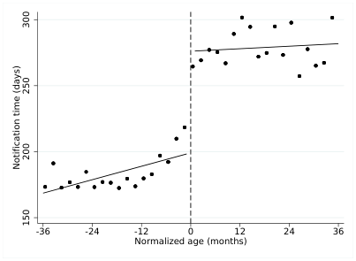

NOTE: figure/graphic rendered as an image from the PDF; its content is not machine-readable text. Caption (if any) follows as the next block.

**text found inside the figure**

150 200 250 300 Notification time (days)

-36 -24 -12 0 12 24 36 Normalized age (months)

(b) MN Effect on Severance Pay

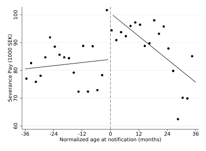

NOTE: figure/graphic rendered as an image from the PDF; its content is not machine-readable text. Caption (if any) follows as the next block.

**text found inside the figure**

60 70 80 90 100 Severance Pay (1000 SEK)

-36 -24 -12 0 12 24 36 Normalized age at notification (months)

**Panel (a)** shows notification times by age at notification in 2-month-bins. The estimated jump at the threshold is 80.8 days,

with a standard error of 8.1. **Panel (b**) shows severance pay by age at notification in 2-month-bins. The estimated jump at

the threshold is 16.9 kSEK, with a standard error of 6.4. **Both Panels:** The regression lines come from estimating equation (2)

with a linear age polynomial interacted with the threshold indicator for individuals aged 52-58 at the time of notification.

The regression also includes baseline covariates (earnings in the year prior to notification, gender, immigrant status, tenure,

educational attainment FEs) and month-by-year FE:s.

Figure 3: Effect of Mandated Notice (MN) on Employment

(a) Probability of Remaining at the Notifying Firm

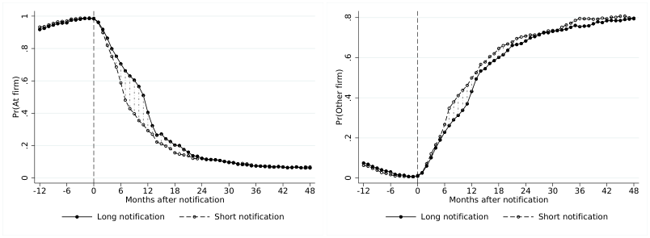

NOTE: figure/graphic rendered as an image from the PDF; its content is not machine-readable text. Caption (if any) follows as the next block.

**text found inside the figure**

0 .2 .4 .6 .8 1 Pr(At firm)

-12 -6 0 6 12 18 24 30 36 42 48 Months after notification

Long notification Short notification

0 .2 .4 .6 .8 Pr(Other firm)

-12 -6 0 6 12 18 24 30 36 42 48 Months after notification

Long notification Short notification

(b) Probability of Working at a New Firm

Notes: The figures show employment outcomes by month relative to notification. At any given point in time, we plot

estimates of the constant (hollow circles) and the constant+β (black circles) from a regression corresponding to equation (2).

Dashed lines indicate that the estimate of β is significant at the 5% level. These regressions include a linear age polynomial

interacted with threshold, baseline covariates (earnings in the year prior to notification, gender, immigrant status, tenure,

educational attainment FEs), and month-by-year FE:s. The analysis only includes individuals aged 52-58 at the time of

notification.

25

Electronic copy available at: https://ssrn.com/abstract=3928666

Page 29

Table 2: Effect of Mandated Notice (MN) on Employment

Cumulated duration in months over a 2-year-horizon

|  | (1) | (2) | (3) | (4) | (5) |
| --- | --- | --- | --- | --- | --- |
|  | Atnotifyingfirm | Atotherfirm | Non-employed | Unemployed | Outoflaborforce |
| Above age-55 | 1815∗∗∗ . | 1047∗∗∗ - . | 0769∗∗∗ - . | 0540∗∗∗ - . | 0228∗∗ - . |
|  | (0262) . | (0303) . | (0203) . | (0155) . | (0113) . |
| Controlmean | 8999∗∗∗ . | 11036∗∗∗ . | 3965∗∗∗ . | 3259∗∗∗ . | 0706∗∗∗ . |
|  | (0230) . | (0274) . | (0166) . | (0125) . | (0077) . |
| R2 | 0065 . | 0058 . | 0018 . | 0020 . | 0006 . |
| #observations | 8856 , | 8856 , | 8856 , | 8856 , | 8856 , |

NOTE: table converted from PDF layout to HTML text; cell boundaries are reconstructed. See PDF if exact alignment matters.

Notes: Time out of the labor force is calculated as time in non-employment minus time in unemployment. Standard errors

are clustered on notification event(3803 clusters). Regressions include individuals aged 52-58 at the time of notification.

The regressions include a linear age polynomial interacted with threshold, baseline covariates (earnings in the year prior to

notification, gender, immigrant status, tenure, educational attainment FEs), and month-by-year FE:s. *<sup>∗</sup>*p < 0.1, *<sup>∗∗</sup>*p < 0.05, *∗∗∗*p < 0.01.

Figure 4: Effect of Mandated Notice (MN) on Initial Re-employment Wage and Wage Evolution

(a) Effect of MN on Re-employment Wage

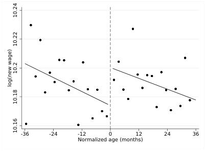

NOTE: figure/graphic rendered as an image from the PDF; its content is not machine-readable text. Caption (if any) follows as the next block.

**text found inside the figure**

10.16 10.18 10.2 10.22 10.24 log(new wage)

-36 -24 -12 0 12 24 36 Normalized age (months)

(b) Wages Evolution Since Notification

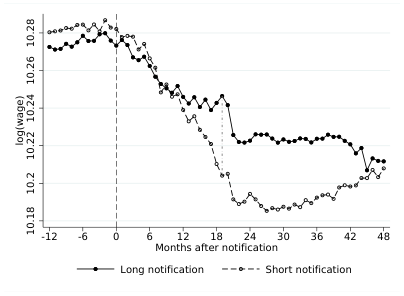

NOTE: figure/graphic rendered as an image from the PDF; its content is not machine-readable text. Caption (if any) follows as the next block.

**text found inside the figure**

10.18 10.2 10.22 10.24 10.26 10.28 log(wage)

-12 -6 0 6 12 18 24 30 36 42 48 Months after notification

Long notification Short notification

**Panel (a)** shows the log of the full-time equivalent monthly wage by age at notification in 2-month-bins around 55. The

esitmated jump at the threshold is 0.027 with a standard error of 0.015. **Panel (b)** shows the log monthly wage by month

relative to notification. At any given point in time, we plot estimates of the constant (hollow circles) and the constant

plus the discontinuity at 55 (black circles). Dashed lines indicate when the discontinuity is significant at the 5% level.

**Both Panels:** The regressions come from estimating equation (2) with a linear age polynomial interacted with the threshold

indicator for individuals aged 52-58 at the time of notification. The regressions also includes baseline covariates and month-

by-year FE:s.

26

Electronic copy available at: https://ssrn.com/abstract=3928666

Page 30

Table 3: Effect of MN on Re-employment Wage and Subsequent Wage Growth

|  | (1) (2) (3) (4) |
| --- | --- |
| Panela | Re-employmentwage EEindicator |
|  | ln(w) ∆ln(w) ∆ln(w) |
| Aboveage-55 | 0027∗ 0031∗ 0002 0038 . . . . |
|  | (0015) (0017) (0034) (0036) . . . . |
| Aboveage-55×EE | 0036 . |
|  | (0038) . |
| EEindicator | 0038 . |
|  | (0026) . |
| Controlmean | 10173∗∗∗ 0086∗∗∗ 0112∗∗∗ 0702∗∗∗ . - . - . . |
|  | (0011) (0012) (0022) (0027) . . . . |
| #clusters | 1787 1287 1287 1287 , , , , |
| #observations | 3056 2363 2363 2363 , , , , |
| Panelb | Wagegrowthsincestartofnewjob |
|  | 1year 2years 3years 4year |
| Aboveage-55 | 0019∗ 0019∗ 0009 0018 . . - . - . |
|  | (0010) (0011) (0014) (0017) . . . . |
| Controlmean | 0008 0020∗∗ 0073∗∗∗ 0106∗∗∗ . . . . |
|  | (0007) (0008) (0010) (0012) . . . . |
| #clusters | 1363 1168 931 751 , , |
| #observations | 2187 1834 1453 1112 , , , , |

NOTE: table converted from PDF layout to HTML text; cell boundaries are reconstructed. See PDF if exact alignment matters.

**Panel (a):** The difference in wages is taken relative to the wage in the year prior to notification. The EE-indicator equals

unity when a worker is observed making an Employment-to-Employment transition. **Panel (b):** Annual wage growth is

defined relative to the initial wage for all individuals (movers as well as stayers) for whom we observe subsequent wages.

**Both Panels:** The estimated regressions correspond to equation (2) and include a linear age polynomial interacted with the

threshold indicator for individuals aged 52-58 at the time of notification. The regressions also include baseline covariates

(earnings in the year prior to notification, gender, immigrant status, tenure, educational attainment FEs) and month-by-year

FE:s. Standard errors are clustered by notification event. *<sup>∗</sup>*p < 0.1, *<sup>∗∗</sup>*p < 0.05, *<sup>∗∗∗</sup>*p < 0.01.

27

Electronic copy available at: https://ssrn.com/abstract=3928666

Page 31

Figure 5: Effect of MN on Earnings

(a) Earnings in the year after notification by age at notification

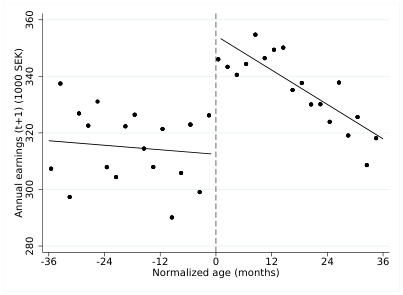

NOTE: figure/graphic rendered as an image from the PDF; its content is not machine-readable text. Caption (if any) follows as the next block.

**text found inside the figure**

280 300 320 340 360 Annual earnings (t+1) (1000 SEK)

-36 -24 -12 0 12 24 36 Normalized age (months)

(b) Annual earnings by years relative to notification

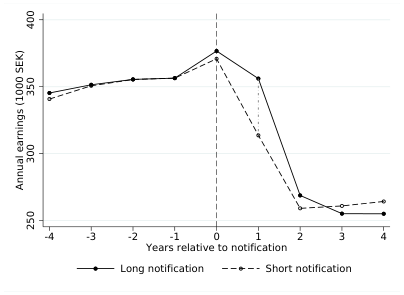

NOTE: figure/graphic rendered as an image from the PDF; its content is not machine-readable text. Caption (if any) follows as the next block.

**text found inside the figure**

250 300 350 400 Annual earnings (1000 SEK)

-4 -3 -2 -1 0 1 2 3 4 Years relative to notification

Long notification Short notification

**Panel (a**): The estimated jump at the threshold is 42.4 kSEK, with a standard error of 6.0. Age at notification is in 2-month-

bins. **Panel (b)** shows annual earnings by year relative to notification. At any given point in time, we plot estimates of

the constant (hollow circles) and the constant plus the discontinuity at 55 (black circles). Dashed lines indicate when the

discontinuity is significant at the 5% level. **Both Panels:** The regressions come from estimating equation (2) with a linear age

polynomial interacted with the threshold indicator for individuals aged 52-58 at the time of notification. The regressions

also include baseline covariates (gender, immigrant status, tenure, educational attainment FEs) and month-by-year FE:s.

28

Electronic copy available at: https://ssrn.com/abstract=3928666

Page 32

Table 4: Separating the Effects of Advance Notice and Severance Pay

|  | Notificationtime | Reducedforms Severancepay | Non-employ. Δln(wage) |
| --- | --- | --- | --- |
|  | (days) | (1000SEK) | (Months) |
|  | (1) (2) | (3) (4) | (5) (6) |
| Above55 (Indicator0/1) | 80877*** 80181*** . . (6508) (6354) . . | 16863** 16346** . . (6664) (6490) . . | 0702*** 0033* - . . (0259) (0018) . . |
| Sharecoworkersabove55 (0 1) - | 31623* . (18643) . | 54518*** . (14886) . | 1629*** 0015 . - . (0408) (0017) . . |
| Notificationtime(months) |  |  | Instrumentalvariables 0542*** 0018* - . . (0196) (0009) . . |
| Severancepay(SEK1000) , |  |  | 0035*** 0000 . - . (0012) (0001) . . |
| Controls Assignmentvariable(ownage) | X X | X X | X X |
| (1st order interacted w. threshold) , MonthbyyearFEs Individualcovariates Size of lay-off | X X X X X | X X X X X | X X X X X X |
| Firmcovariates(includesage) Industry(1digit)FEs | X X | X X | X X X X |
| Estimationstatistics 1st stage F -statistic #clusters(notificationevents) #observations(RF) | 15442 8082 . . 3803 3780 , , 48797 48655 , , | 640 903 . . 3760 3770 , , 46474 45083 , , | -- -- 3770 2309 , , 48568 13273 , , |

NOTE: table converted from PDF layout to HTML text; cell boundaries are reconstructed. See PDF if exact alignment matters.

**Panel (a)** shows reduced-form estimates, while **Panel (b)** shows instrumental variables estimates. The sample includes

all white-collar workers in notification events where a white-collar worker aged 52-58 was notified. Sample size varies

marginally across columns 1-5 since we do not observe firm covariates and severance pay for all observations; the drop in

sample size in column (6) is due to sampling in the wage survey. The regression specifications are such that the effect of

the Above 55 indicator is identified within the sample of white-collar workers aged 52-58, while share co-workers above 55

is identified across all white-collar workers. “Individual covariates” are: earnings in the year prior to notification, gender,

immigrant status, tenure, educational attainment FEs. Standard errors are clustered by notification events.

29

Electronic copy available at: https://ssrn.com/abstract=3928666

Page 33

Figure 6: Distribution of Layoff Size by Incentives to Bunch

(a) Density of Layoff Size: closing vs. not

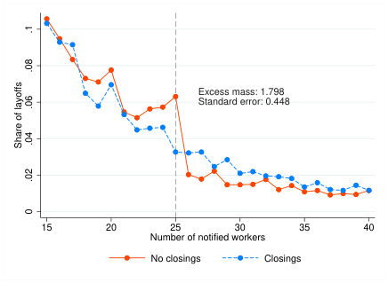

NOTE: figure/graphic rendered as an image from the PDF; its content is not machine-readable text. Caption (if any) follows as the next block.

**text found inside the figure**

Excess mass: 1.798 Standard error: 0.448

0 .02 .04 .06 .08 .1 Share of layoffs

15 20 25 30 35 40 Number of notified workers

No closings Closings

(b) Bunching Estimates by Share of Short Notice

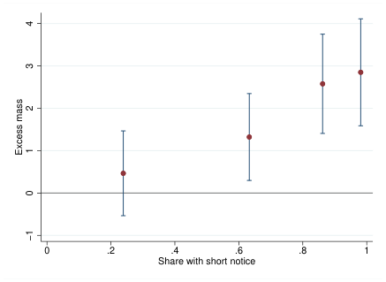

NOTE: figure/graphic rendered as an image from the PDF; its content is not machine-readable text. Caption (if any) follows as the next block.

**text found inside the figure**

−1 0 1 2 3 4 Excess mass

0 .2 .4 .6 .8 1 Share with short notice

Employers are required to report to the Public Employment Service at least four months before any layoff of more than

25 workers. **Panel (a)** shows the distribution of layoff size for events that are due to closings (blue dashed line) and non-

closings (red solid line) around the 25-threshold. We report estimated excess bunching, obtained as the difference between

the non-closing density and the closing density for layoff events of sizes 22-25. We then normalize this difference by the

share of layoffs in closing establishments that include 25 workers (the counterfactual density). We estimate standard errors

by bootstrapping layoff events with replacement one hundred times. **Panel (b)** divides layoff events into four equally sized

groups by the share of laid off workers with a mandated notification period which is shorter than four months. For each

quartile, we plot the excess mass estimate as in Panel A against the average share of laid off workers with short notice. The

counterfactual density consists of closing events, and we use the same counterfactual density for all four groups.

30

Electronic copy available at: https://ssrn.com/abstract=3928666

Page 34

Figure 7: Productivity Loss of Notification

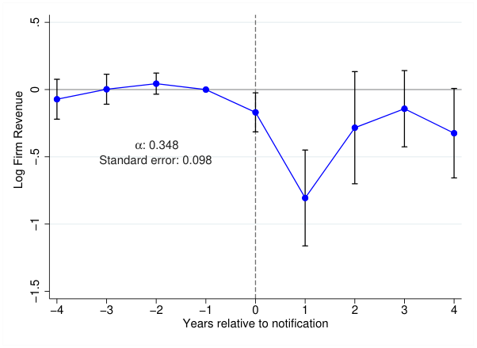

NOTE: figure/graphic rendered as an image from the PDF; its content is not machine-readable text. Caption (if any) follows as the next block.

**text found inside the figure**

α: 0.348 Standard error: 0.098

−1.5 −1 −.5 0 .5 Log Firm Revenue

−4 −3 −2 −1 0 1 2 3 4 Years relative to notification

Notes: This figure shows estimates of event-time fixed effects αt from Equation 7. In a panel of notifications, we regress the

log of winsorized annual firm revenue (winsorization at the 1st and 99th percentile) on event-time dummies, notification

fixed effects, log of number of months worked by all workers, average age of workers, as well as relative layoff size and

the share of months worked during notice interacted with event-time dummies. The reported α-estimate in the figure

pools event-times 0 and 1 to obtain the total production loss due to notification. The panel is balanced until time 0 and

includes 74,591 notification-year observations. Standard errors are clustered on notification event and the figure displays

95% confidence intervals.

31

Electronic copy available at: https://ssrn.com/abstract=3928666

Page 35

Figure 8: Effects of Mandated Notice (MN) on Severance Pay: Cash-Constrained vs -Unconstrained Firms

(a) Severance for Unconstrained Firms

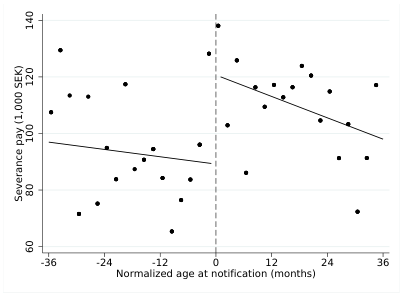

NOTE: figure/graphic rendered as an image from the PDF; its content is not machine-readable text. Caption (if any) follows as the next block.

**text found inside the figure**

60 80 100 120 140 Severance pay (1,000 SEK)

-36 -24 -12 0 12 24 36 Normalized age at notification (months)

(b) Severance for Constrained Firms

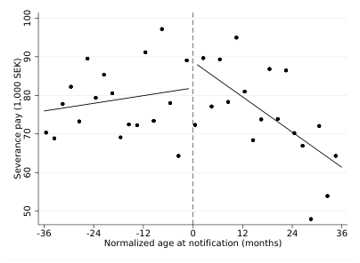

NOTE: figure/graphic rendered as an image from the PDF; its content is not machine-readable text. Caption (if any) follows as the next block.

**text found inside the figure**

50 60 70 80 90 100 Severance pay (1,000 SEK)

-36 -24 -12 0 12 24 36 Normalized age at notification (months)

**Panel (a)** shows severance pay by age at notification in 2-month-bins for unconstrained firms, defined as firms with the

share of liquid assets over total assets above the mean. **Panel (b)** is analogous but focuses on constrained firms. **Both**

**Panels:** The regression lines come from estimating equation (2) with a linear age polynomial interacted with the threshold

indicator for individuals aged 52-58 at the time of notification. The regressions also include baseline covariates earnings in

the year prior to notification, gender, immigrant status, tenure, educational attainment FEs) and month-by-year FE:s.

32

Electronic copy available at: https://ssrn.com/abstract=3928666

Page 36

### **A Online Appendix: Theoretical part**

This section of the online appendix provides a more detailed description and omitted analysis of our

theoretical work.

#### **A.1 Setting**

We consider a two-period model where production is the results of a match between a worker and

an employer. Workers are homogeneous and risk-neutral. Risk neutrality assumption is a deviation

from the literature. It allows us to focus on the first-order efficiency gain of advance notice instead

of the second-order gain through provision of insurance. Employers are also homogeneous and risk

neutral. For now, there is free entry and perfect competition among employers.

In the first period, production is “high”, denoted by Y. In the second period, production remains

high with probability θ or drops to zY with probability 1 −θ, where θ *∈*[0, 1) and z *∈*[0, 1).

At the beginning of the two periods, employers and employees match, with no search friction and

write and sign a contract. The contract specifies a wage, a severance payment and an advance notice

requirement, (wY, sY, δ *∈*{0, 1}). Without loss of generality, we normalize Y = 1. The contracted wage

is fixed for both periods, with no possibility of renegotiation. This assumption leads to separation

in case of a productivity drop in the second period. For sake of simplicity, we assume no time

discounting or interest rate.

Employer learns

productivity profile Advance Notice

1 2 Layoff

On the job search Shirking

↑job finding rate ↑job productivity

Trade-off 𝛼𝛼𝑌𝑌 σ𝑌𝑌

**equation / math rendering (image)**

[figure not shown]

NOTE: contains mathematical notation; text above is the PDF text layer and symbols may be mis-extracted. Image shows the original.

Productivity always 𝑌𝑌 Productivity may fall to z𝑌𝑌

- Homogeneous risk-neutral workers - Homogeneous employers with free entry - Match & Contract

Production loss Production gain

New job

Time

Figure A1: The Setting and The Timing of the Events

33

Electronic copy available at: https://ssrn.com/abstract=3928666

Page 37

Just after signing the contract, the employer receives private information about the productivity

of the match in the second period. The information is verifiable: the employer may share this

information with the employee, i.e., giving her advance notice, at the start of the first period.

If an employee receive an advance notice, her productivity falls as she starts both to look for

alternative employment (on-the-job search) and shirks given her lower incentives. These two forces

together lead to a lower production at the first period equal to (1 −α) Y, where α *∈*[0, 1) measures

the total production loss. Without lose of generality, from here on, we use Y as the numeraire from

here onward.

Safe jobs are available in the second period, with the productivity ρ, where ρ *∈*[0, 1) captures

the displacement effect. Laid-off worker will find such a job with likelihood e. To make the setting

interesting to study, we assume that it is efficient to separate in the second low-productivity period,

i.e. the production loss is large relative to the outside option,

eρ > z. (A1)

On the job search is productive. It increases both the likelihood of finding a job in the second

period by ∆e and the wage in the new job by ∆ρ (Acemoglu and Shimer (1999), Faberman et al.

(2021)). We denote the total expected production increase due to notice by σ,

σ *≡*(e + ∆e) (ρ + ∆ρ) −eρ. (A2)

To focus on productive efficiency, we ignore the disutility cost of working and searching. To

incorporate such costs, we would have to adjust eρ and σ.

The most efficient on-the-job search would lead to finding a job with probability one with no

displacement effect. This gives an upper bound for σ, that is

1 −eρ ⩾σ. (A3)

The trade-off in providing notice is between the production loss of notice, α, and the production

gain due to on-the-job search for the worker, σ. First-best information sharing (advance notice) occurs

when the productivity loss in the first period is smaller than the gain from notice, i.e., if and only if

α < σ. By contrast, providing severance pay does not involve the same trade-off since it lacks the

information sharing aspect.

#### **A.2 Exogenous contract**

In this section, we study the role of MN in the case of an exogenous contract without advance notice, (w, s, 0). This is a partial equilibrium analysis – in fact, it is the counterpart of Baily-Chetty setting for

the analysis of optimal UI, applied to the case of advance notice (Baily (1978); Chetty (2006)).

Layoff incentive compatibility (IC) condition assures layoff at low-productivity state: the cost of

layoff to the employer is lower than cost of labor hoarding in the low-productivity second period:

w −z ⩾s (A4)

34

Electronic copy available at: https://ssrn.com/abstract=3928666

Page 38

No layoff at high-productivity implies that s ⩾w −1.

Employers do not provide advance notice. This is independently of how much gains of providing

notice are larger than its cost, since employers do not internalize the gain occurring to the employee

but bear the cost. The expected profit would be

π0 = (1 −w) | {z } 1st period

+ θ *×* (1 −w) + (1 −θ) *×* (−s) | {z } 2nd period

(A5)

or

π0 = (1 + θ) (1 −w) −(1 −θ) s (A6)

Total production or welfare is

W0 = 1 + θ + (1 −θ) eρ

Now if the labor law mandate an advance notice, employer faces three options when receiving the

bad news of productivity drop. First is to provide advance notice, reducing the expected profit by the

production loss due to notice, π0 −(1 −θ) α.

The second option is to not provide advance notice but compensate the worker ex post with an

additional severance payment of σ. This would leads to the expected profit π0 −(1 −θ) σ.

The third option is to notify the worker but later so that the productivity loss happens during the

low productivity period. This labor hoarding strategy leads to the profit of π0 −(1 −θ) Ξ where

Ξ *≡*w −(1 −α) z. (A7)

Layoff IC implies that Ξ > s + αz.

So the optimal choice of the employer is

1. To notify the worker in advance iff

α = min (σ, α, Ξ) (A8)

This condition is the advance notice IC condition and consists of two parts. First part assures that

notice is ex post better than compensation using severance: the production loss of notice is smaller

than the ex post additional severance payment needed to avoid the lawsuit, σ > α. The second part

is about timing of notice and assures that early notice is preferred by the employer relative to late

notice,

w −(1 −α) z > α (A9)

35

Electronic copy available at: https://ssrn.com/abstract=3928666

Page 39

1

Production loss due to AN 𝛼𝛼 0 1

45<sup>𝑜𝑜</sup>

**equation / math rendering (image)**

NOTE: contains mathematical notation; text above is the PDF text layer and symbols may be mis-extracted. Image shows the original.

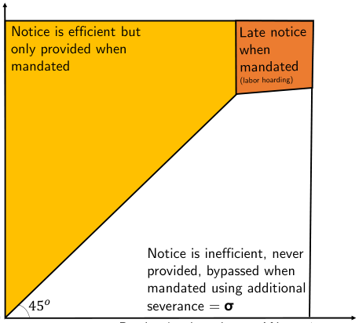

NOTE: figure/graphic rendered as an image from the PDF; its content is not machine-readable text. Caption (if any) follows as the next block.

**text found inside the figure**

Notice is efficient but only provided when mandated

Notice is inefficient, never provided, bypassed when mandated using additional severance = **σ**

On the job search relative effectiveness

#### **σ**

Figure A2: Exogenous contract and MN period = 1 Note: This figure shows the provision of notice decided by the employer in the absence and presence of MN, where the duration of the notice period is 1. Exogenous contract includes wage and severance, but not advance notice.

The welfare/production gain in this case would be ∆W = (1 −θ) σ.

2. To keep the worker uninformed but pay her off at the time of layoff iff the profit loss due to

notice is higher than the gain to the worker σ = min (σ, α, Ξ). There is no welfare gain in this case.

3. To retain the worker in the second period when Ξ = min (σ, α, Ξ): the cost of notice to employer

and its benefit to the employee both are higher than the relative benefit of layoff to labor hoarding.

Note that the condition Ξ = min (σ, α, Ξ) can be written as α > <sup>w</sup><sup>−</sup><sup>z</sup>

The contracted severance does not matter, except satisfying in the layoff IC, condition A4.

Moreover, the likelihood of the productivity fall, θ, does not matter either, since all decisions are taken

conditional on productivity fall, and there is no substitution of resources between the two states.

Using these three equilibrium outcomes, the total labor earning increase for notified workers can

be written as:

P3 |{z} MN effect on earnings from old job

+ P1σ −P3eρ | {z } MN effect on earn. from new job

+ P2σ |{z} MN effect on severance pay

(A10)

36

Electronic copy available at: https://ssrn.com/abstract=3928666

Page 40

where Pi represent the share of workers in each case. We can rewrite this equation as

P1∆e + P3 | {z } non-employment dur. effect

−P1 (1 −ρ) ∆e |{z} new job dur. effect

+ P1e ∆ρ |{z} wage effect

+ P2σ |{z} Severance pay effect

(A11)

that would be the base of the decomposition of earnings in Section 3.1. Except the severance pay term,

the other components of the decomposition together constitute the production gain of MN.

1

Production loss due to AN 𝛼𝛼 0 1

45<sup>𝑜𝑜</sup>

**equation / math rendering (image)**

NOTE: contains mathematical notation; text above is the PDF text layer and symbols may be mis-extracted. Image shows the original.

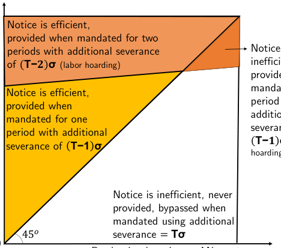

NOTE: figure/graphic rendered as an image from the PDF; its content is not machine-readable text. Caption (if any) follows as the next block.

**text found inside the figure**

Notice is efficient but only provided when mandated

Notice is efficient, provided when mandated for one period with additional severance of **T−1 σ**

Notice is efficient, provided when mandated for two periods with additional severance of **T−**𝟐𝟐**σ** (labor hoarding)

Notice is inefficient, never provided, bypassed when mandated using additional severance = **Tσ**

On the job search relative effectiveness

#### **σ**

Notice is inefficient, provided when mandated for one period with additional severance of

**T−**𝟏𝟏**σ** (labor hoarding)

Figure A3: Exogenous contract, with MN duration of T ⩾2 Note: This figure shows the provision of notice decided by the employer in the absence and presence of MN, where the duration of the notice period is T ⩾2. Exogenous contract includes wage and severance, but not advance notice.

**Extension 1** In the main framework, we consider the case where the duration of MN has been

equal to the duration of the information horizon of the firm. One concern with MN is that it may

require information sharing before even the employer has the information, i.e. the MN duration

longer than the information horizon. We can model this in our setting by assuming that the law

mandate notice T period in advance, T ⩾2.

Under this law, all the three options discusses above are possible but in each case an additional

severance payment of (T −1) σ must be paid to the worker to compensate for the additional length of

MN. In this sense, too long MN is equivalent to well-timed MN plus a mandatory severance.

In addition, now employer has a forth option, providing two periods of notification. This will lead

to profit of π0 −(1 −θ) (Ξ + (T −2) σ + α).

37

Electronic copy available at: https://ssrn.com/abstract=3928666

Page 41

Employer choice is then driven by minimizing the cost, so choosing the minimum of (σ, α, Ξ, Ξ + α −σ). This leads to decisions illustrated in Figure A3 that are as follows:

1. To notify the worker in advance for one period iff α < σ < Ξ.

2. To keep the worker uninformed but pay her off at the time of layoff iff σ = min (σ, α, Ξ).

3. To retain the worker in the second period and provide her one period of notice iff Ξ < σ < α.

4. To retain the worker in the second period and provide her two periods of notice iff σ =

max (σ, α, Ξ). In this case, the notice given is too long and inefficient.

We conclude that when MN period is longer than firm’s information horizon, mandating notice

is equivalent to mandating severance pay, unless when the benefit of on-the-job search σ is large. In

that case, firm provide too long notice although it is inefficient since it is too costly to use severance

instead.

**Extension 2** To capture the hiring cost of MN, we assume production is the result of match

between one worker and one unit of capital. The latter is elastically supplied, capital supply κ (.)

is an increasing function of the return. Then in the absence of mandating, the return and employment

rate would be κ (π0) = l0.

Employment rate in the first period is l0. In the second period from the e share of (1 −θ) l0 newly

laid-off workers will find a safe job, so that employment rate would be θl0 + e (1 −θl0).

Mandating notice reduces the expected profit by (1 −θ) *×* min (α, σ, Ξ) that leads to lower hiring.

κ (π0 −(1 −θ) *×* min (α, σ, Ξ)) = lM (A12)

Lower hiring is at least partially offset with late layoff when labor hoarding. The second period

the same as the first when min (α, σ, Ξ) = Ξ. The counter-veiling force in case of notice is the higher

job finding rate, ∆e. But when severance is used to bypass the MN, there is no counter-veiling force.

#### **A.3 Endogenous contract**

Free entry of firms and perfect competition among firms imply that equilibrium contract have

zero expected profit and maximize the worker’s utlity (similar to CITE). We thus solve the utility

maximizing contract in each case.

#### **A.3.1 Absence of mandated advance notice (MN)**

Using the Revelation principle, we confine our attention to direct revelation contracts.

First option is to **layoff without notice**. In this case, agent utility is driven by the wages plus in

case of layoff an additional severance and expected income from the new job.

u<sup>L</sup> = max

w,s w |{z} 1st period + θ *×* w + (1 −θ) *×* (s + eρ) | {z } 2nd period

(A13)

under two constraints of the layoff IC (A4) and profit zero:

1 + θ = w + θw + (1 −θ) s (A14)

38

Electronic copy available at: https://ssrn.com/abstract=3928666

Page 42

There is no difference between wage and severance unless in the layoff IC (A4). The latter is

satisfied with a high wage and low severance, e.g. w<sup>L</sup> = 1, s<sup>L</sup> = 0, where wage is equal to the

marginal product with no layoff cost. This leads to utility level of

u<sup>L</sup> = 1 + θ + (1 −θ) eρ (A15)

Note the irrelevance of production fall in period two, z.

This dominates retain contracts, u<sup>R</sup> = Y where Y = 1 + θ + (1 −θ) z is the expected production of

a match in the absence of separation. Retain contract itself dominates the strategy of late notification:

notifying the worker at the end of the first period and lay him off at the end of the second period.

Second option is to **layoff with notice**

u<sup>N</sup> = max

w,s w |{z} 1st period + θ *×* w + (1 −θ) *×* (s + eρ + σ) | {z } 2nd period

(A16)

under two constraints of advance notice IC (A8) and profit zero:

1 + θ = w + θw + (1 −θ) (s + α) (A17)

This leads to:

u<sup>N</sup> = 1 + θ + (1 −θ) (eρ + σ −α) . (A18)

This dominates a contract where on-the-job search is allowed at all time. The quit contract,

u<sup>q</sup> = 1 + eρ + σ −α, is dominated either by u<sup>L</sup> or u<sup>N</sup>.

**Negative severance** Severance must be negative when production loss due to notice is high

relative to shock likelihood and magnitude, that is

Negative severance is the price of on-the-job search that worker pay when search is effective

for employee and search/shirking is costly to employer. One problem is that worker quit with

negative severance. A solution is that contract states that severance is paid when notice is given

and independently of the type of separation. Severance becomes the price of advance notice (and

on-the-job search). Note that the cutoff for α is a function of the magnitude of the productivity shock,

the larger is the shock, the more likely the contract has negative severance.

39

Electronic copy available at: https://ssrn.com/abstract=3928666

Page 43

1

Production loss due to AN 𝛼𝛼 0 1

45<sup>𝑜𝑜</sup>

**equation / math rendering (image)**

NOTE: contains mathematical notation; text above is the PDF text layer and symbols may be mis-extracted. Image shows the original.

On the job search effectiveness

#### **σ**

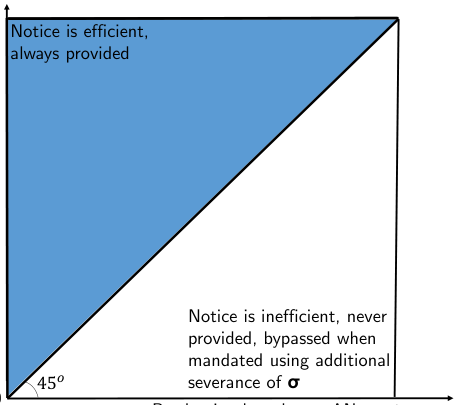

NOTE: figure/graphic rendered as an image from the PDF; its content is not machine-readable text. Caption (if any) follows as the next block.

**text found inside the figure**

Notice is efficient, always provided

Notice is inefficient, never provided, bypassed when mandated using additional severance of **σ**

Figure A4: Endogenous Contract with no Friction Note: This figure shows the provision of notice decided by the employer in the absence and presence of MN, where the duration of the notice period is 1. Endogenous contract may include wage, severance, and advance notice.

#### **A.3.2 Mandating notice**

When advance notice is mandated, then employer can follow the law leading to the same situation as

a private contract with notice that we studied in the previous section, i.e. u<sup>N</sup>

M <sup>=</sup><sup>u</sup><sup>N</sup><sup>.</sup><sup>42</sup>

Sidestepping the law, employer can layoff the worker without advance notice and compensate

her ex-post with an additional severance of σ. The equilibrium contract will be the result of following

optimization:

u<sup>L</sup>

M *<sup>≡</sup>*<sup>max</sup>

w,s w |{z} 1st period + θ *×* w + (1 −θ) *×* (s + σ + eρ) | {z } 2nd period

(A20)

under three constraints of

w −z > s + σ (A21)

α > σ (A22)

1 + θ = w + θw + (1 −θ) (s + σ) (A23)

This is similar problem than the optimization of (A13) with the difference that total severance is

the contracted severance, s, plus the additional compensating severance, σ. This additional severance

42A retain contract is again dominated here as well.

40

Electronic copy available at: https://ssrn.com/abstract=3928666

Page 44

compensates for lack of advance notice and undo the mandate. The second condition, (A22), is also

new relative to (A13). It assures that employer does not provide notice ex post.

Worker obtains the same utility as the case of private contract with no notice, u<sup>L</sup>

M <sup>=</sup> <sup>u</sup><sup>L</sup><sup>.</sup> <sup>The</sup>

difference is that wage adjusted to leave room for the compensating severance.<sup>43</sup> Thus there is no

change in allocations by the mandate, but only different contracts. In particular, the amount of notice

does not change, while total severance paid (not necessarily contracted severance) is increased in

response to the mandate. This also means that the mandate has no employment effect. This is in

spirit of Lazear (1990).

Total severance paid, sum of contracted and compensating severance, can be always set to be

non-negative. That said, the contracted severance is negative when

1 + θ 2 (1 −z) < σ (A24)

In contrast to the case of no MN, the negative contracted severance here is not the price of advance

notice, but rather an initial payment for the additional severance that firm will later pay to undo the

mandate.

#### **A.4 Endogenous contract with Frictions**

Worker misperceives the stability of the job, <sup>b</sup>θ > θ. This is similar to the under-saving assumption in

the Baily model. But the difference is that we allow for a rich set of contracts, as if augment the Baily

setting would allow the firms to provide UI. In addition, we require that severance pay is limited

from below and above, namely, s ⩾s ⩾0. These limits represent two additional source of frictions,

namely firms and worker cash-constraints.

#### **A.4.1 Absence of mandate**

Layoff contracts are not affected by the misperception, but their perceived utility are different, for the

contract without notice, the utility achieved is

bu<sup>L</sup> = 1 + <sup>b</sup>θ +

1 −<sup>b</sup>θ

eρ (A25)

and for the contract with notice

bu<sup>N</sup> = 1 + <sup>b</sup>θ +

1 −<sup>b</sup>θ

(eρ + σ −κα) (A26)

where κ *≡*<sup>1</sup><sup>−</sup><sup>θ</sup>

bu<sup>N</sup> > bu<sup>L</sup> *⇔*σ > κα (A27)

So that misperception κ > 1 implies an under provision of notice in private contracts.<sup>44</sup>

43More precisely, wL M <sup>=</sup><sup>1</sup><sup>−</sup><sup>1</sup><sup>−</sup><sup>θ</sup>

1+θ

σ + s<sup>L</sup>

M

. 44The retain contract gives the same utility as before and it is dominated.

41

Electronic copy available at: https://ssrn.com/abstract=3928666

Page 45

1

Production loss due to AN 𝛼𝛼 0 1

45<sup>𝑜𝑜</sup>

**equation / math rendering (image)**

NOTE: contains mathematical notation; text above is the PDF text layer and symbols may be mis-extracted. Image shows the original.

On the job search effectiveness

#### **σ**

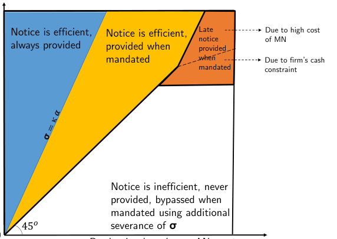

NOTE: figure/graphic rendered as an image from the PDF; its content is not machine-readable text. Caption (if any) follows as the next block.

**text found inside the figure**

Notice is efficient, provided when mandated

Notice is efficient, always provided

Notice is inefficient, never provided, bypassed when mandated using additional severance of **σ**

Late notice provided when mandated

Due to high cost of MN

Due to firm’s cash constraint

Figure A5: Endogenous contract with frictions Note: This figure shows the provision of notice decided by the employer in the absence and presence of MN. There are three frictions: Worker misperceives the stability of the job, <sup>b</sup>θ > θ, firms and worker cash-constraints so that neither can promise a large severance, s ⩾s ⩾0. The mandated duration of the notice period is 1. Endogenous contract may include wage, severance, and advance notice.

#### **A.4.2 Mandating notice**

If employer follows the law and provide notice, then the worker utility in equilibrium will be the

same as in A26, bu<sup>N</sup>

M <sup>=</sup> <sup>b</sup><sup>u</sup><sup>N</sup><sup>.</sup>

If employer ignores the law and do not provide notice but instead compensate the worker with an

additional severance, then

bu<sup>L</sup>

**equation / math rendering (image)**

NOTE: contains mathematical notation; text above is the PDF text layer and symbols may be mis-extracted. Image shows the original.

M <sup>=</sup><sup>1</sup><sup>+</sup><sup>b</sup><sup>θ</sup><sup>+</sup>

1 −<sup>b</sup>θ

(eρ −(κ −1) σ) (A28)

relative to no mandate, equation A25, worker utility is shifted only through her

misperception.Then

bu<sup>N</sup>

**equation / math rendering (image)**

NOTE: contains mathematical notation; text above is the PDF text layer and symbols may be mis-extracted. Image shows the original.

M <sup>></sup> <sup>b</sup><sup>u</sup><sup>L</sup>

M *<sup>⇔</sup>*<sup>σ > α</sup> (A29)

So the equilibrium seems to be back to efficient allocation of notice. The intuition for this result is

that once notice is mandated, firm becomes the decision maker and correct the misperception of the

worker.

The caveat is that the retain contract, that leads to perceived utility bu<sup>R</sup>

M <sup>=</sup> <sup>Y</sup><sup>,</sup> <sup>is</sup> <sup>not</sup> <sup>always</sup>

dominated when workers underestimate the likelihood of productivity loss. Safe a contract so the

42

Electronic copy available at: https://ssrn.com/abstract=3928666

Page 46

risk perception does not matter. In fact, the retain contract can be optimal when

σ > α & α

κ −<sup>1</sup><sup>−</sup><sup>θ</sup>

1 −<sup>b</sup>θ z

−σ > Γ (A30)

or when

α > σ & σ (κ −1) −<sup>1</sup><sup>−</sup><sup>θ</sup>

1 −<sup>b</sup>θ zα > Γ (A31)

where

Γ *≡*

**equation / math rendering (image)**

NOTE: contains mathematical notation; text above is the PDF text layer and symbols may be mis-extracted. Image shows the original.

bθ −θ

1 −<sup>b</sup>θ (1 −z) + eρ −z (A32)

The former case corresponds to when bu<sup>R</sup>

M <sup>></sup> <sup>b</sup><sup>u</sup><sup>N</sup>

M <sup>></sup> <sup>b</sup><sup>u</sup><sup>L</sup>

than notice and a contract with notice is better than a severance contract. And in the latter case, bu<sup>R</sup>

M <sup>></sup> <sup>b</sup><sup>u</sup><sup>L</sup>

M <sup>></sup> <sup>b</sup><sup>u</sup><sup>N</sup>

that the retain contract is dominated. For example, conditions A30 is equivalent to σ > α > <sup>σ</sup><sup>+</sup><sup>eρ</sup><sup>−</sup><sup>z</sup>

1−z in this case, that is impossible since <sup>σ</sup><sup>+</sup><sup>eρ</sup><sup>−</sup><sup>z</sup>

1−z > σ.

If misperception is small relative to the firm cash-constraint, then the latter become binding and

prevent the usage of severance instead of inefficient notice. To be precise, this is the case when

s

κ −1 −<sup>1</sup><sup>−</sup><sup>θ</sup>

1 −<sup>b</sup>θ z

< Γ

#### **A.5 Endogenous contract with Friction: Unemployment Insurance (UI)**

In this section, we study a setting where the friction stems from an unbalanced-budget UI system.

Such system subsidizes unemployment and thus creates inefficiency in provision of advance notice

in private contracts.

#### **A.5.1 Absence of mandated advance notice**

First option is to **layoff without notice**. In this case, agent optimization is similar to (A13) with the

difference that it incorporates UI benefit and taxes:

u<sup>L</sup> = max

w,s w −τ | {z } 1st period + θ *×* (w −τ) + (1 −θ) *×* (s + (1 −e) b + e (ρ −τ)) | {z } 2nd period

(A33)

under two constraints of the layoff IC (A4) and profit zero of (A14). Given the similarity in the setting,

the solution is also similar to the case without UI (optimization (X)). This leads to final utility level of:

u<sup>L</sup> = 1 + θ + (1 −θ) eρ −T <sup>L</sup> (A34)

where T <sup>L</sup> denotes the fiscal externality of the worker on the UI system:

T <sup>L</sup> *≡*τ −b + E<sup>L</sup> (τ + b)

43

Electronic copy available at: https://ssrn.com/abstract=3928666

Page 47

E denotes the total employment rate, that is

E<sup>L</sup> *≡*θ + (1 −θ) e. (A35)

The utlity of contract without notice are changed by the amount of fiscal externality they create,

compare (A15) and (A34).

Second option is to **layoff with notice**, again the agent problem and its solution are similar to the

case with no UI, namely

u<sup>N</sup> = max

w,s w −τ | {z } 1st period + θ *×* (w −τ) + (1 −θ) *×* (s + (1 −e −∆e) b + (e + ∆e) (ρ + ∆ρ −τ)) | {z } 2nd period

(A36)

under two constraints of advance notice IC (A8) and profit zero of (A14). This leads to:

u<sup>N</sup> = 1 + θ + (1 −θ) (eρ + σ −α) −T <sup>N</sup>. (A37)

where the fiscal externality is now

T <sup>N</sup> *≡*τ −b + E<sup>N</sup> (τ + b)

The employment rate is now higher due to notice,

E<sup>N</sup> *≡*E<sup>L</sup> + (1 −θ) ∆e (A38)

where ∆e is Mn effect on employment in the second period, that constitutes one of the two elements

of the productivity gain of MN, σ (see the equation (A2)).

The equilibrium contract is then determined by the comparison of the benefit and cost of MN, σ

and α, but also the MN effect on the size of subsidy received by the worker:

u<sup>N</sup> ⩾u<sup>L</sup> *⇔*σ ⩾α + (τ + b) ∆e (A39)

So the fiscal bias in treament of the two contract creates an extra wedge and thus inefficiency by

inducing the choice of contract with higher unemployment risk.

Note that we assumed an additive pay-roll tax. The condition (A39) would be very similar if we

have used a proportional tax. The only difference would be the wedge on the right hand side would

be b 1−τ<sup>∆e</sup><sup>, instead.</sup>

#### **A.5.2 Mandating notice**

When advance notice is mandated, then employer can follow the law leading to the same situation as

a private contract with notice that we studied in the previous section, i.e. u<sup>N</sup>

M <sup>=</sup><sup>u</sup><sup>N</sup><sup>.</sup> <sup>A retain contract</sup>

is always dominated now.

Sideste‘pping the law, employer can layoff the worker without advance notice and compensate

her ex-post with an additional severance of σ. The equilibrium contract will be the result of following

44

Electronic copy available at: https://ssrn.com/abstract=3928666

Page 48

optimization:

u<sup>L</sup>

M *<sup>≡</sup>*<sup>max</sup>

w,s w −τ | {z } 1st period + θ *×* (w −τ) + (1 −θ) *×* (s + eσ + (1 −e) b + e (ρ −τ)) | {z } 2nd period

(A40)

under three constraints of

w −z > s + eσ (A41)

α > eσ (A42)

1 + θ = w + θw + (1 −θ) (s + eσ) (A43)

where

eσ = σ −(τ + b) ∆e

This is similar problem than the optimization of (A20) with the difference that the compensating

severance is lowered by the fiscal wedge between employment and unemployment. This leads to the

utility, u<sup>L</sup>

M <sup>=</sup><sup>u</sup><sup>L</sup><sup>.The fiscal externality of MN is</sup>

T <sup>N</sup> −T <sup>L</sup> = (τ + b) (1 −θ) ∆e (A44)

### **B Online Appendix: Empirical Part**

#### **B.1 RDD Validity Tests**

A possible concern is that firms try to selectively displace low-cost workers, along the lines of the

insider-outsider theory (see Lindbeck and Snower, 1989). In our setting, this would manifest itself

through more laid-off workers just to the left of the age-55 threshold. Figure A6 examines whether

there is manipulation around the age-55 threshold by comparing the number of observations in the

vicinity of the threshold. There is no evidence of suspect bunching on either side of the threshold.

Table A1 investigates whether baseline covariates are evenly distributed across the age-55

threshold. Columns (1)-(4) examine overall balancing. We regress an indicator for being above

the age-55 threshold on all baseline characteristics and polynomial control functions in age. We

are mainly interested in the F-statistics, reported at the bottom end of the table, which test the null

hypotheses that all coefficients on individual (and firm) characteristics are jointly zero. As indicated

by the p-values of the F-tests we cannot reject these hypotheses. Also, the individual coefficients are

typically small.

Column (5) reports bivariate tests of equality of baseline covariates above and below the threshold.

These tests reinforce the view that the coefficients are generally small: those just above the threshold

earned 0.26% less than those just below the threshold, for instance.

45

Electronic copy available at: https://ssrn.com/abstract=3928666

Page 49

Figure A6: Number of observations by age at notification

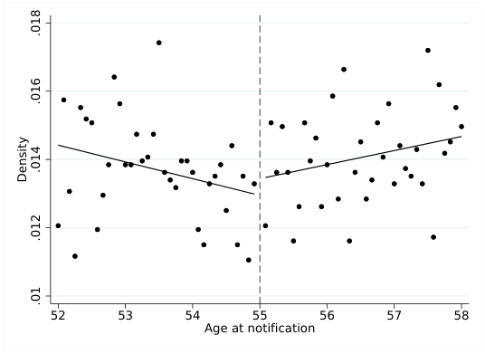

NOTE: figure/graphic rendered as an image from the PDF; its content is not machine-readable text. Caption (if any) follows as the next block.

**text found inside the figure**

.01 .012 .014 .016 .018 Density

52 53 54 55 56 57 58 Age at notification

Notes: The figure shows the distribution of displaced individuals by age at notification (measured in months). The

regression lines come from estimating a regression corresponding to equation (2) with the fraction of observations at each

age bin as the outcome variable. The regression includes a linear age polynomial interacted with the threshold dummy. The

estimated jump at the threshold is 0.0005 (standard error = 0.0006, p-value = 0.435).

46

Electronic copy available at: https://ssrn.com/abstract=3928666

Page 50

Table A1: Balancing of pre-determined covariates

|  | (1) | (2) | (3) | (4) | (5) |
| --- | --- | --- | --- | --- | --- |
| Earningst−1 | 00029 - . | 00028 - . | 00040 - . | 00001 - . | 00026 - . |
|  | (00062) . | (00066) . | (00066) . | (00040) . | (00174) . |
| Female | 00035 . | 00037 . | 00037 . | 00002 . | 00128 . |
|  | (00049) . | (00052) . | (00055) . | (00033) . | (00215) . |
| Immigrant | 00033 - . | 00028 - . | 00027 - . | 00009 - . | 00012 . |
|  | (00093) . | (00091) . | (00092) . | (00062) . | (00146) . |
| Tenure(years) | 00035 - . | 00035 - . | 00045 - . | 00015 - . | 00496 - . |
| Highestattainededucation | (00030) . | (00030) . | (00032) . | (00020) . | (00334) . |
| Primary | 00252 - . | 00224 - . | 00211 - . | 00016 . | 00052 . |
|  | (00230) . | (00232) . | (00226) . | (00151) . | (00129) . |
| Highschool | 00301 - . | 00277 - . | 00281 - . | 00040 - . | 00399∗ - . |
|  | (00196) . | (00197) . | (00193) . | (00119) . | (00233) . |
| College | 00189 - . | 00175 - . | 00182 - . | 00015 . | 00295 . |
|  | (00219) . | (00216) . | (00212) . | (00137) . | (00232) . |
| Firmcharacteristics |  | ✓ | ✓ | ✓ |  |
| Polynomialorder |  |  |  |  |  |
| 1stdegree | ✓ | ✓ | ✓ |  | ✓ |
| 2nddegree |  |  |  | ✓ |  |
| Interactedw threshold . | ✓ | ✓ | ✓ | ✓ | ✓ |
| Month/YearFE |  |  | ✓ | ✓ | ✓ |
| F -statistic | 120 . | 138 . | 155 . | 118 . | · |
| p-value | 0312 . | 0196 . | 0126 . | 0311 . | · |
| R2 | 0768 . | 0768 . | 0768 . | 0905 . | · |
| #observations | 8860 , | 8860 , | 8860 , | 8860 , | 8954 8893 , – , |

NOTE: table converted from PDF layout to HTML text; cell boundaries are reconstructed. See PDF if exact alignment matters.

Notes: Earnings are measured relative to the control group. Standard errors are clustered on notitication event. Regressions

include individuals aged 52-58 at the time of notification. Columns (1)-(4) show the results of regressing an indicator for

being above the age–55 threshold on baseline covariates and polynomial control functions in age. The bottom part of the

table reports the F-statistic and the associated p-value from testing the null hypothesis that all coefficients on (individual

and firm) baseline covariates are jointly zero. Firm characteristics included in columns (2)-(4) are workforce characteristics –

average earnings, share of females, share of immigrants, average age, share of college-educated, and number of employed.

All firm characteristics are balanced, except average age in columns (2) and (3) (for instance, in column (2) average age is

0.0008 years higher for individuals above the age-55 threshold). Column (5) reports the results of bivariate balancing tests

where each covariate listed in the left-hand column is regressed on the treatment indicator and an interacted first order

polynomial control function in age at notification. *<sup>∗</sup>*p < 0.1, *<sup>∗∗</sup>*p < 0.05, *<sup>∗∗∗</sup>*p < 0.01

#### **B.2 Optimal bandwidth**

Figure A7 reproduces Figure 3 but with the optimal bandwidth selector of Calonico et al. (2014). The

figure is built from 48 separate RD-regressions, and, consequently, there are 48 optimal bandwidths.

In general, optimal bandwidths are in between 2.0 and 4.0 years, and our default bandwidth of 3 is

thus well in-line with the optimal ones. There are instances when bandwith-selector picks 1.8 or 4.5

years as the optimal ones, but these are rare occasions.

The most important message from A7, however, is that none of our results change when we use

47

Electronic copy available at: https://ssrn.com/abstract=3928666

Page 51

this approach rather than the one we opt for in the main text. Conceptually, since age is discrete in

our data, we prefer the parametric approach of the main text. Our default approach also avoids the

slightly cumbersome exercise of using potentially different data sets for each single point estimate.

48

Electronic copy available at: https://ssrn.com/abstract=3928666

Page 52

Figure A7: Employment by month relative to notification (optimal bandwidth)

(a) Probability of remaining at notifying firm

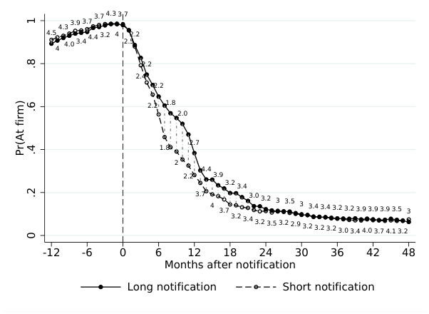

NOTE: figure/graphic rendered as an image from the PDF; its content is not machine-readable text. Caption (if any) follows as the next block.

**text found inside the figure**

4.5 4.3 <sup>3.9 3.7 3.7 4.3 3.7</sup>

2.2

2.2

2.2

1.8

2.0

2.7

4.4 3.9 3.2 3.4 3.0 3.2 3 3.5 3 3.4 3.4 3.2 3.2 3.9 3.9 3.9 3.5 3

4 <sup>4.0 3.4 4.4 3.2</sup> <sup>4</sup> 2.5

2.4

2.2

1.8

2

2.2

3.7

4 3.7 3.2 3.4 3.2 3.5 3.2 2.9 3.2 3.2 3.2 3.0 3.4 4.0 3.7 4.1 3.2

0 .2 .4 .6 .8 1 Pr(At firm)

-12 -6 0 6 12 18 24 30 36 42 48 Months after notification

Long notification Short notification

(b) Probability of working at a new firm

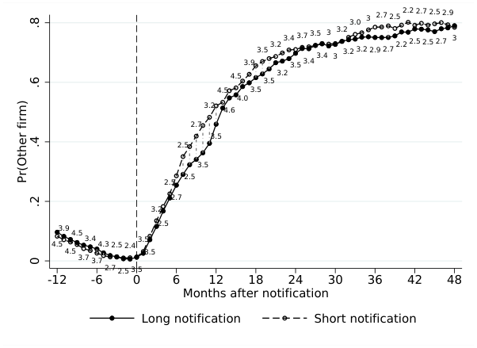

NOTE: figure/graphic rendered as an image from the PDF; its content is not machine-readable text. Caption (if any) follows as the next block.

**text found inside the figure**

4.5 4.5 3.7 3.7 2.7 2.5 3.5

3.5

2.5

2.7

2.5

3.5

3.5

4.6

4.0 3.5 3.5 3.2 3.5 <sup>3.4 3.4</sup> <sup>3</sup> <sup>3.2 3.2 2.9 2.7 2.2 2.5 2.5 2.7</sup> <sup>3</sup>

3.9 4.5 3.4 4.3 2.5 2.4 3.5

3.2

2.5

2.5

2.7

3.2

4.5

4.5

3.9

3.5 <sup>3.2</sup> 3.4 <sup>3.7 3.5</sup> <sup>3</sup> <sup>3.2</sup> 3.0 <sup>3</sup> <sup>2.7 2.5</sup> 2.2 2.7 2.5 2.9

0 .2 .4 .6 .8 Pr(Other firm)

-12 -6 0 6 12 18 24 30 36 42 48 Months after notification

Long notification Short notification

Notes: The figures show each outcome by month relative to notification. At any given time point, we plot estimates of

the constant (hollow circles) and the constant+β (black circles) from a local linear regression corresponding to (2) with a

bandwidth which is indicated by the number above each point in the graph. Dashed lines indicate that the estimate of β

is significant at the 5%-level. The regressions also include baseline covariates (earnings in the year prior to notification,

gender, immigrant status, tenure, educational attainment FEs) and month-by-year FE:s.

49

Electronic copy available at: https://ssrn.com/abstract=3928666

Page 53

#### **B.3 MN Wage Effect**

#### **Decomposition of the MN Wage Effect**

Starting from the decomposition of the expected wage to its average conditional on an

employment-to-employment (EE) transition or not, that is:

w = Pr(EE = 1)wEE=1 + Pr(EE = 0)wEE=0

This implies that the MN wage effect is

∆w = ∆(Pr(EE = 1)wEE=1) + ∆(Pr(EE = 0)wEE=0)

We can rewrite the MN wage effect and use the point estimate of each term from Table 3 as:

∆w |{z} Wage effect

= ∆Pr(EE = 1) (wEE=1 −wEE=0) | {z } EE effect

+ Pr (EE = 1) ∆wEE=1 | {z } wage effect | EE

+ Pr (EE = 0) ∆wEE=0 | {z } wage effect | ~EE 0.031 0.038 *×* 0.038 0.71 *×* 0.037 0.29 *×* 0.001

.001 + .026 + 0.0003

Alternatively, if we use estimates from wage level instead of changes, we obtain similar results,

namely:

Pr (EE) E (ln w|EE) = 0.7 *×* 0.04 = 2.8%

#### **Role of Sorting in the MN Wage Effect**

Higher firm quality partly explain our positive wage effects. The next Table estimates the effect

of longer MN on characteristics of the new firm. We measure all outcomes in the year prior to

notification, and thus before the worker joins the firm, so that the firm outcomes are not affected

by the worker himself. With varying statistical significance, longer notification is associated with

higher wages, higher earnings, older workers, smaller firms, higher profits, profit margins, and value

added.

50

Electronic copy available at: https://ssrn.com/abstract=3928666

Page 54

Table A2: Mandatory Notice (MN) Effect on Firm Sorting

**Panel a:** Firm Characteristics using individual-level data

(1) (2) (3) (4) (5) (6)

Log(New firm wage) Log(New firm earnings) Share males Mean age Log(firm size) New firm size>

old firm size

Above age-55 0.010 0.116*∗∗* 0.007 0.817*∗∗* -0.099 -0.021

(0.018) (0.050) (0.012) (0.358) (0.154) (0.030)

Control mean 10.260*∗∗∗* 11.878*∗∗∗* 0.554*∗∗∗* 40.965*∗∗∗* 5.826*∗∗∗* 0.431*∗∗∗*

(0.011) (0.038) (0.009) (0.261) (0.114) (0.020)

N 2566 4967 4965 4966 4967 4967

**Panel b:** Firm Characteristics using firm-level data

Sales new firm > Profit new firm > Profit/VA new firm > VA new firm > Log(Value Added) Labor share

Sales old firm Profit old firm Profit/VA old firm VA old firm

Above age-55 -0.006 0.024 0.011 -0.032 0.016 -0.032

(0.024) (0.029) (0.028) (0.021) (0.210) (0.036)

Control mean 0.251*∗∗∗* 0.529*∗∗∗* 0.598*∗∗∗* 0.278*∗∗∗* 10.571*∗∗∗* 0.461*∗∗∗*

(0.015) (0.019) (0.018) (0.014) (0.165) (0.027)

N 4142 4142 4003 4142 3894 3874

Notes: All outcomes are measured in the year before the individual is notified and thus before joining the new firm. **Panel (a)** outcomes are workers characteristics. *New firm wage* and *New firm*

*earnings* refer to the average monthly wage and annual earnings of the new firm, respectively. **Panel (b)** focuses on outcomes based on the balance sheets and income statements of firms. Labor

share is defined as total labor costs including payroll taxes divided by value added. Standard errors, reported in parentheses, are clustered on notification event. Regressions include individuals

aged 52-58 at the time of notification. The regressions include a linear age polynomial interacted with the threshold indicator, baseline covariates (earnings in the year prior to notification,

gender, immigrant status, tenure, educational attainment FEs), and month-by-year FE:s. *∗*p < 0.1, *∗∗*p < 0.05, *∗∗∗*p < 0.01.

51

Electronic copy available at: https://ssrn.com/abstract=3928666

Page 55

Figure A8: Effects of eligibility for long Advance Notice (AN) on the distribution of wage changes

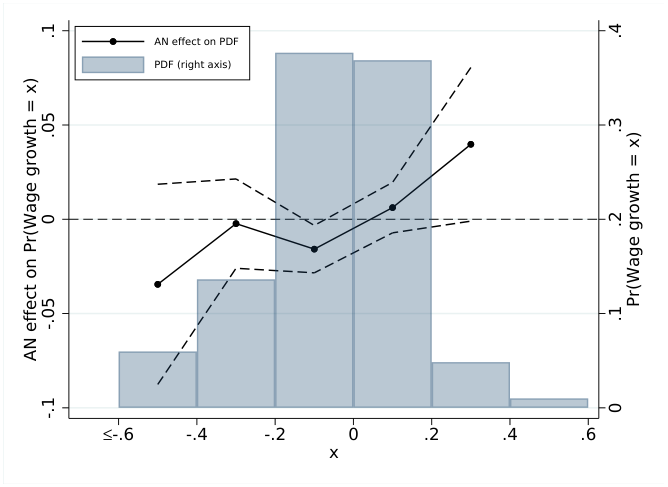

NOTE: figure/graphic rendered as an image from the PDF; its content is not machine-readable text. Caption (if any) follows as the next block.

**text found inside the figure**

0 .1 .2 .3 .4

Pr(Wage growth = x)

-.1 -.05 0 .05 .1 AN effect on Pr(Wage growth = x)

≤-.6 -.4 -.2 0 .2 .4 .6 x

AN effect on PDF

PDF (right axis)

Notes: The figures plots the MN effect on the PDF of wage growth distribution on the left y-acix (marked solid line) and

corresponding confidence intervals (dashed line), the PDF itself is on the right y-axis. The regression lines come from

estimating equation (2) with a linear age polynomial interacted with the threshold indicator. The regressions also include

baseline covariates (earnings in the year prior to notification, gender, immigrant status, tenure, educational attainment FEs)

and month-by-year FE:s. The analysis only includes individuals aged 52-58 at the time of notification.

52

Electronic copy available at: https://ssrn.com/abstract=3928666

Page 56

#### **B.4 Additional Results**

Table A3: Effects of MN on advance notice duration, specification analysis

|  | (1) | (2) | (3) | (4) | (5) | (6) |
| --- | --- | --- | --- | --- | --- | --- |
| Above age-55 | 78370∗∗∗ . | 80821∗∗∗ . | 81889∗∗∗ . | 50148∗∗∗ . | 51008∗∗∗ . | 55499∗∗∗ . |
|  | (8409) . | (8119) . | (6698) . | (11498) . | (10158) . | (9330) . |
| Controlmean | 198043∗∗∗ . | 196489∗∗∗ . | 200176∗∗∗ . | 217832∗∗∗ . | 216710∗∗∗ . | 216506∗∗∗ . |
|  | (6200) . | (5766) . | (4702) . | (8790) . | (6875) . | (6265) . |
| Polynomialorder |  |  |  |  |  |  |
| 1stdegree | ✓ | ✓ | ✓ |  |  |  |
| 2nddegree |  |  |  | ✓ | ✓ | ✓ |
| Baselinecovariates | ✓ | ✓ | ✓ | ✓ | ✓ | ✓ |
| Interactedw threshold . |  | ✓ | ✓ |  | ✓ | ✓ |
| Month/YearFEs |  | ✓ |  |  | ✓ |  |
| DisplacementeventFEs |  |  | ✓ |  |  | ✓ |
| F -stat | 8687 . | 9910 . | 14947 . | 1902 . | 2522 . | 3538 . |
| R2 | 0091 . | 0186 . | 0245 . | 0092 . | 0187 . | 0247 . |
| #observations | 8955 , | 8860 , | 8860 , | 8955 , | 8860 , | 8860 , |

NOTE: table converted from PDF layout to HTML text; cell boundaries are reconstructed. See PDF if exact alignment matters.

Notes: Standard errors are clustered on notification event (3803 clusters). Regressions include individuals aged 52-58 at

the time of notification. Baseline covariates are earnings in the year prior to notification, gender, immigrant status, tenure,

educational attainment FEs. *<sup>∗</sup>*p < 0.1, *<sup>∗∗</sup>*p < 0.05, *<sup>∗∗∗</sup>*p < 0.01

53

Electronic copy available at: https://ssrn.com/abstract=3928666

Page 57

Two sources of approximation are (i) earnings and wage effects are estimated on two *calendar* year

horizon; (ii) the wage effects are estimated on a subsample of the baseline population. Despite the

approximations involved in the decomposition, the estimated and imputed severance pay effect line

up remarkably well, leading to the following decomposition:

∆y w0 |{z} Earnings effect of MN

= − ∆NE | {z } non-employment dur. effect

−

w0 −w1

w0

∆l1 |{z} new job dur. effect

+ <sup>∆w</sup><sup>1</sup>

w0 | {z }

l1

wage effect

+ ∆SP

w0 |{z} Severance pay effect

(A45)

Table A4: Decomposition of 2-year cumulative earnings effect

|  | Component/monthlywage | Percentofearningseffect |
| --- | --- | --- |
| Component |  |  |
| Employmenteffects |  |  |
| non-employment | 0796 . | 50 |
| newjob | 0056 . | 4 |
| Wageeffects |  |  |
| wageatnewjob | 0314 . | 20 |
| imbalanceininitialwage | 0148 - . | 9 - |
| Estimatedseverancepayeffect | 0559 . | 35 |
| Imputedseverancepayeffect | 0544 . |  |
| Sumofestimatedcomponents | 1578 . | 100 |
| Estimatedearningseffect | 1563 . |  |

NOTE: table converted from PDF layout to HTML text; cell boundaries are reconstructed. See PDF if exact alignment matters.

Notes: Estimated earnings effect = ∆y/w<sup>L</sup>

(w<sup>L</sup>

0 <sup>−</sup><sup>w</sup><sup>L</sup> 1 <sup>)</sup><sup>∆l</sup><sup>1</sup>

/w<sup>L</sup>

0 <sup>.</sup>

Wage effects: wage at new job =

l<sup>S</sup>

1 <sup>w</sup><sup>S</sup> 1 <sup>∆</sup><sup>ln</sup><sup>w</sup><sup>1</sup>

/w<sup>L</sup>

l<sup>S</sup>

0 <sup>w</sup><sup>S</sup> 0 <sup>∆</sup><sup>ln</sup><sup>w</sup><sup>0</sup>

/w<sup>L</sup>

0 <sup>(notice that the difference in</sup>

pre-treatment wages is insignificant; it equals -0.014 (SE = 0.015)). Estimated severance pay effect = ∆SP/w<sup>L</sup>

0 <sup>.</sup> <sup>The index</sup><sup>L</sup><sup>(</sup><sup>S</sup><sup>) denotes</sup>

eligibility for long (short) notification. The employment effects come from Table 2, the wage estimate from column (2) of Table 3, the

severance pay from Figure 2b.

54

Electronic copy available at: https://ssrn.com/abstract=3928666

Page 58

Figure A9: Earnings for workers for whom January is the last month with the notifying firm

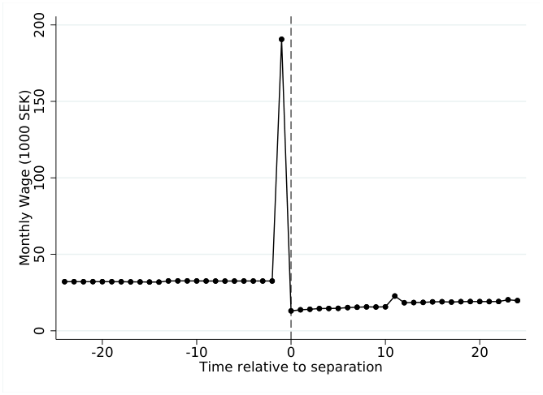

NOTE: figure/graphic rendered as an image from the PDF; its content is not machine-readable text. Caption (if any) follows as the next block.

**text found inside the figure**

0 50 100 150 200 Monthly Wage (1000 SEK)

-20 -10 0 10 20 Time relative to separation

Notes: Monthly earnings for workers whose last recorded month with the notifying firm is January in the year of

displacement.

55

Electronic copy available at: https://ssrn.com/abstract=3928666

Page 59

Figure A10: Employment outcomes by age at notification

(a) Probability of remaining at the notifying firm 12 months after notification

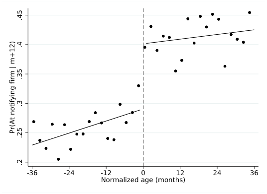

NOTE: figure/graphic rendered as an image from the PDF; its content is not machine-readable text. Caption (if any) follows as the next block.

**text found inside the figure**

.2 .25 .3 .35 .4 .45 Pr(At notifying firm | m+12)

-36 -24 -12 0 12 24 36 Normalized age (months)

(b) Probability of working at a new firm 12 months after notification

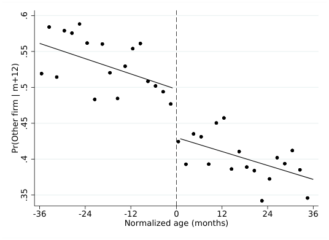

NOTE: figure/graphic rendered as an image from the PDF; its content is not machine-readable text. Caption (if any) follows as the next block.

**text found inside the figure**

.35 .4 .45 .5 .55 .6 Pr(Other firm | m+12)

-36 -24 -12 0 12 24 36 Normalized age (months)

Notes: The figures show employment outcomes by age at notification (2-month-bins). The regression lines come from

estimating equation (2) with a linear age polynomial interacted with the threshold indicator. The estimated jump at the

threshold in **panel (a)** is 11.2 percentage points, with a standard error of 2.3 ppt, while the estimated jump at the threshold

in **panel (b)** is -6.8 percentage points, with a standard error of 2.4 ppt. The regressions also include baseline covariates

(earnings in the year prior to notification, gender, immigrant status, tenure, educational attainment FEs) and month-by-

year FE:s. The analysis only includes individuals aged 52-58 at the time of notification.

56

Electronic copy available at: https://ssrn.com/abstract=3928666

Page 60

Figure A11: Probability of working at the first firm by months since employment start

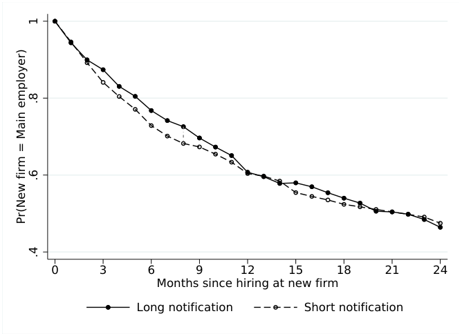

NOTE: figure/graphic rendered as an image from the PDF; its content is not machine-readable text. Caption (if any) follows as the next block.

**text found inside the figure**

.4 .6 .8 1 Pr(New firm = Main employer)

0 3 6 9 12 15 18 21 24 Months since hiring at new firm

Long notification Short notification

Notes: The figure shows the probability of working in the first new firm after notification over time. We define the first

new job after notification as the first month of a new employment spell after the worker has left the notifying firm. The

worker stays with that firm as long as imputed monthly earnings from that firm exceed those from some other firm (in

months when the worker has no earnings from a different firm the threshold is zero). At any given point in time, we plot

estimates of the constant (hollow circles) and the constant+β (black circles) from a regression corresponding to equation (2).

Dashed lines indicates that the estimate of β is significant at the 5% level. These regressions include a linear age polynomial

interacted with the threshold indicator, baseline covariates (earnings in the year prior to notification, gender, immigrant

status, tenure, educational attainment FEs), and month-by-year FE:s. The analysis only includes individuals aged 52-58 at

the time of notification.

57

Electronic copy available at: https://ssrn.com/abstract=3928666

Page 61

Table A5: Balancing tests with respect to share coworkers above age-55

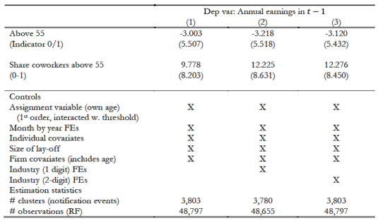

NOTE: figure/graphic rendered as an image from the PDF; its content is not machine-readable text. Caption (if any) follows as the next block.

The table examine whether the earnings a year prior to notification are balanced with respect to the (individual) age-55

indicator and the share coworkers who are above age-55. The sample includes all white-collar workers in notification

events where a white-collar worker aged 52-58 was notified. Sample size varies marginally across columns since we do not

observe firm covariates for all observations. The regression specifications are such that the effect of the Above 55 indicator

is identified within the sample of white-collar workers aged 52-58, while share co-workers above 55 is identified across

all white-collar workers. “Individual covariates” are: earnings in the year prior to notification, gender, immigrant status,

tenure, educational attainment FEs. Standard errors are clustered by notification events.

58

Electronic copy available at: https://ssrn.com/abstract=3928666

Page 62

Figure A12: Spill-over of MN on Co-workers’ Notice

(a)

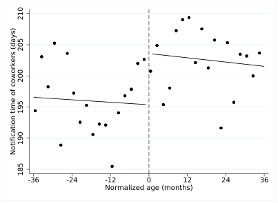

NOTE: figure/graphic rendered as an image from the PDF; its content is not machine-readable text. Caption (if any) follows as the next block.

**text found inside the figure**

185 190 195 200 205 210 Notification time of coworkers (days)

-36 -24 -12 0 12 24 36 Normalized age (months)

(b)

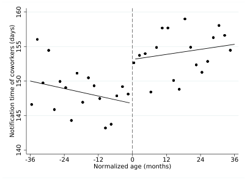

NOTE: figure/graphic rendered as an image from the PDF; its content is not machine-readable text. Caption (if any) follows as the next block.

**text found inside the figure**

140 145 150 155 160 Notification time of coworkers (days)

-36 -24 -12 0 12 24 36 Normalized age (months)

Notes: This graph shows the average actual notice time of the co-workers of a worker around age 55. Panel (a) inludes

only white-collar workers whereas panel (b) also include blue-collar workers. The estimated jump at the threshold is 7.9

days, with a standard error of 3.0 in panel (a). The regression lines come from estimating equation (2) with a linear age

polynomial interacted with the threshold indicator. The regression also includes baseline covariates (earnings in the year

prior to notification, gender, immigrant status, tenure, educational attainment FEs) and month-by-year FE:s.

59

Electronic copy available at: https://ssrn.com/abstract=3928666

Page 63

Figure A13 shows the distribution of the size of layoffs when aggregating layoff events over a

one-year period around the 25-threshold for the years 2005-2015.

Figure A13: Distribution of layoff size aggregated over a one-year period

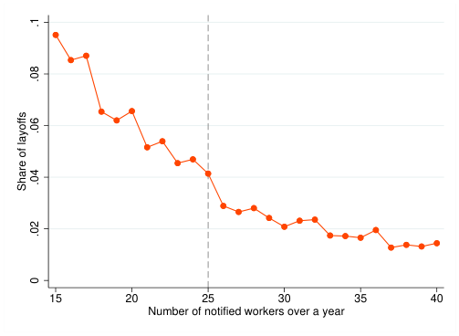

NOTE: figure/graphic rendered as an image from the PDF; its content is not machine-readable text. Caption (if any) follows as the next block.

**text found inside the figure**

0 .02 .04 .06 .08 .1 Share of layoffs

15 20 25 30 35 40 Number of notified workers over a year

Notes: This figure shows the distribution of the layoff size around the 25-threshold when aggregating layoff events over a

one-year period for the years 2005-2015.

60

Electronic copy available at: https://ssrn.com/abstract=3928666